# Practical Homework 3: Deep Learning

# 1. Data Preparation

```python
# 1. Load libraries

import numpy as np
import pandas as pd
import h5py
import random
import time
import scipy.ndimage
import os
import librosa
import cv2

import matplotlib.pyplot as plt
import seaborn as sns
from sklearn.metrics import confusion_matrix, classification_report

from sklearn.preprocessing import LabelEncoder
from sklearn.model_selection import train_test_split
from sklearn.utils import class_weight

import tensorflow as tf
from tensorflow.keras import layers, models
from tensorflow.keras.models import load_model
from tensorflow.keras.models import Sequential
from keras.layers import Dense, Dropout, Conv2D, MaxPooling2D, Flatten, Input

from tensorflow.keras.callbacks import EarlyStopping
from tensorflow.keras.regularizers import l2

from skimage.transform import resize
from tensorflow.keras.utils import to_categorical
from tensorflow.keras.layers import GlobalAveragePooling2D
from tensorflow.keras.optimizers import Nadam
from tensorflow.keras.preprocessing.image import ImageDataGenerator

from tensorflow.keras.layers import Conv2D, MaxPooling2D, Flatten, Dropout, Dense, BatchNormalization, Input
from tensorflow.keras.optimizers import Adam
from tensorflow.keras.callbacks import EarlyStopping, ReduceLROnPlateau
from tensorflow.keras.optimizers import RMSprop
from tensorflow.keras.layers import Activation

from collections import Counter

random.seed(42)
np.random.seed(42)
tf.random.set_seed(42)
```

```python
# 2. Data Reading

f = h5py.File('bird_spectrograms.hdf5', 'r')
print("Available keys:", list(f.keys()))
```

```
Available keys: ['amecro', 'amerob', 'bewwre', 'bkcchi', 'daejun', 'houfin', 'houspa', 'norfli', 'rewbla', 'sonspa', 'spotow', 'whcspa']
```

```python
# 3. Create Dataset

bird_species = ['amecro', 'amerob', 'bewwre', 'bkcchi', 'daejun', 'houfin', 'houspa', 'norfli', 'rewbla', 'sonspa', 'spotow', 'whcspa']

for species_key in bird_species:
    dataset = f[species_key]
    print(f"Species: {species_key}, Shape: {dataset.shape}")
```

```
Species: amecro, Shape: (128, 517, 66)
Species: amerob, Shape: (128, 517, 172)
Species: bewwre, Shape: (128, 517, 144)
Species: bkcchi, Shape: (128, 517, 45)
Species: daejun, Shape: (128, 517, 125)
Species: houfin, Shape: (128, 517, 84)
Species: houspa, Shape: (128, 517, 630)
Species: norfli, Shape: (128, 517, 37)
Species: rewbla, Shape: (128, 517, 187)
Species: sonspa, Shape: (128, 517, 263)
Species: spotow, Shape: (128, 517, 137)
Species: whcspa, Shape: (128, 517, 91)
```

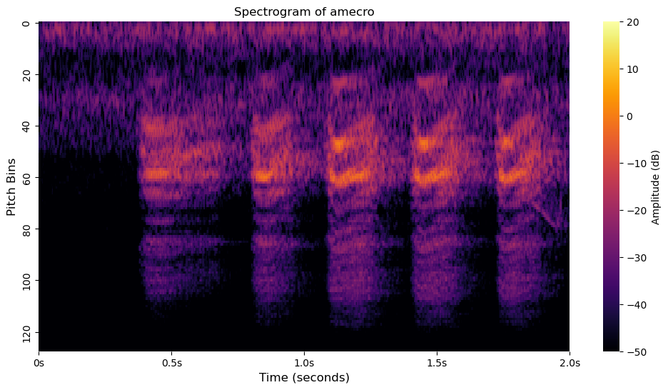

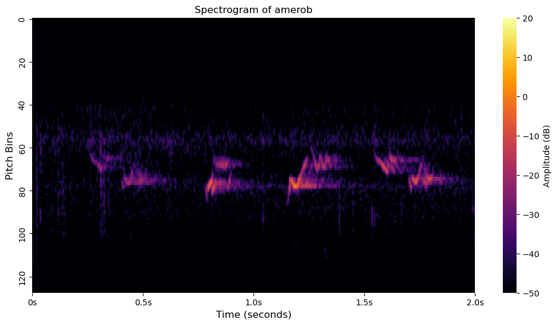

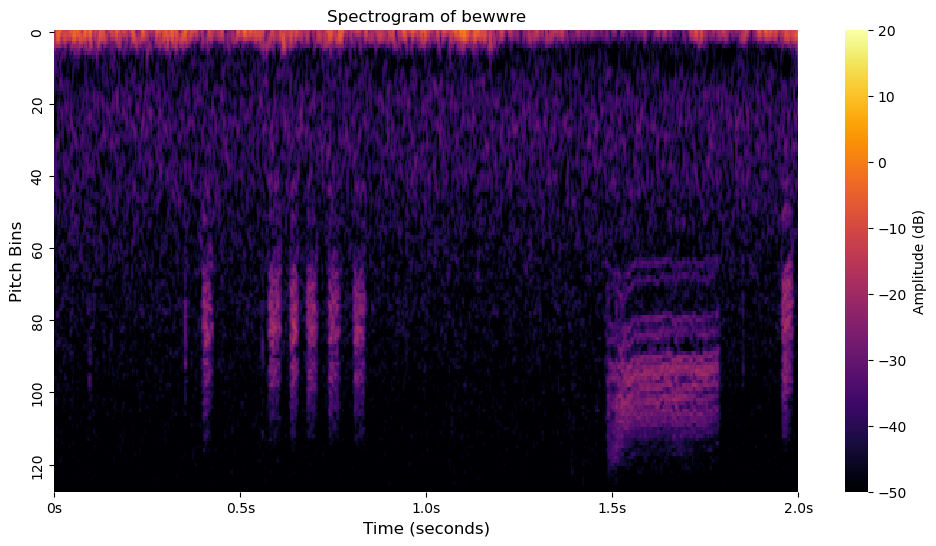

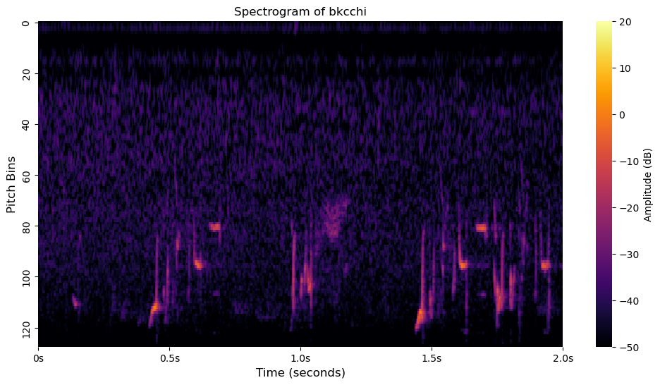

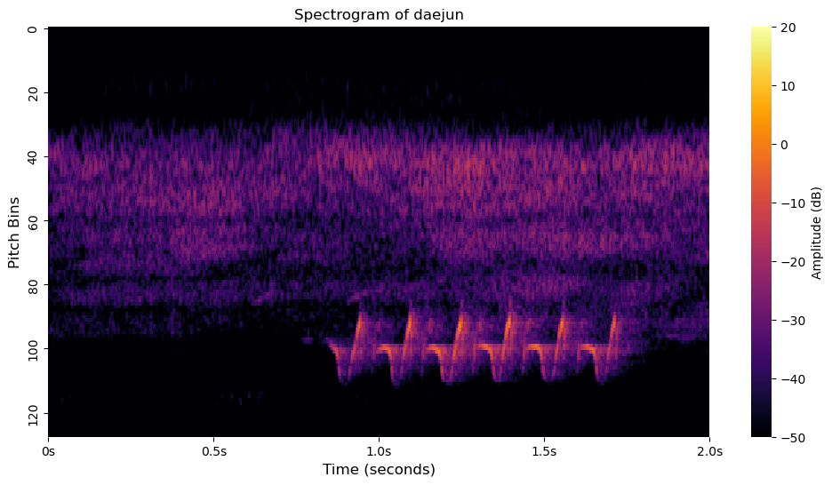

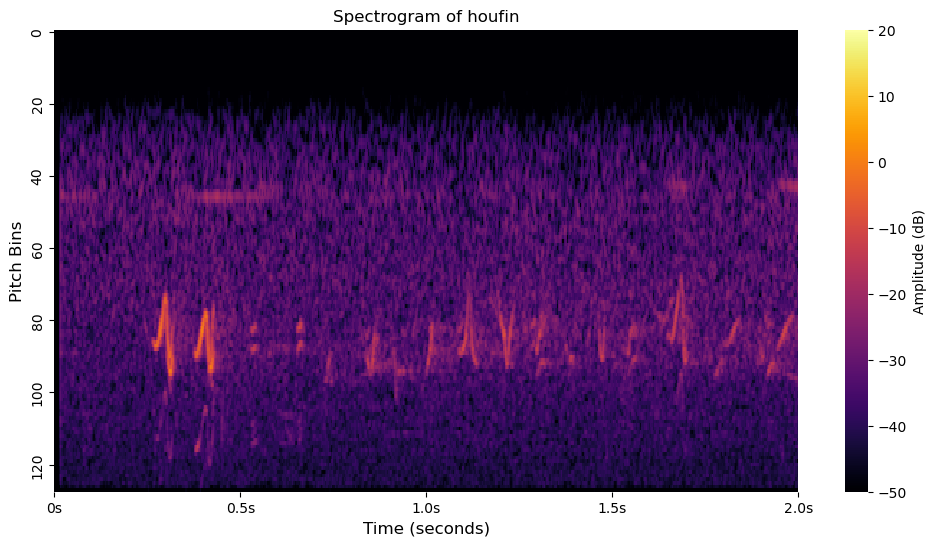

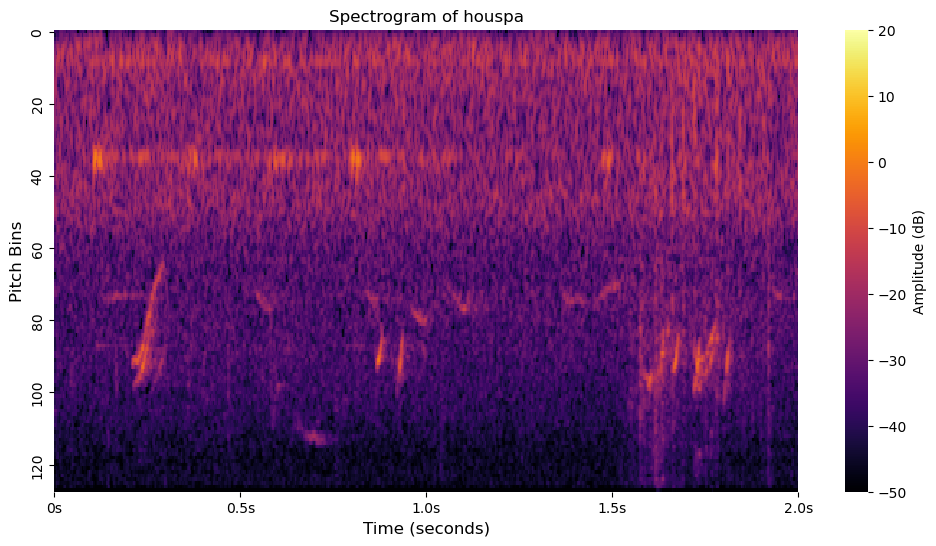

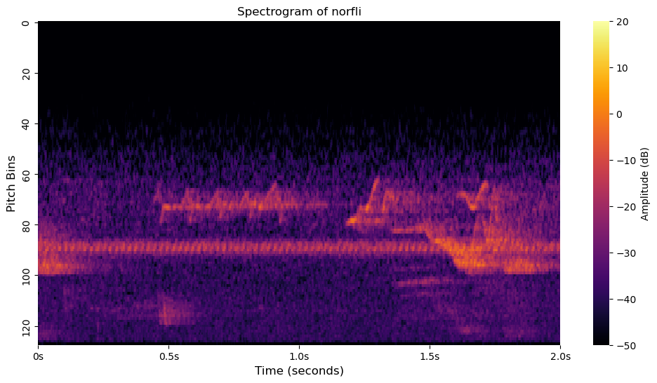

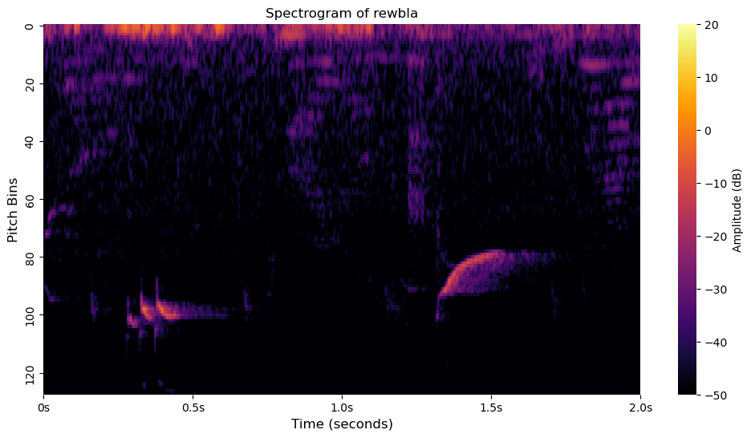

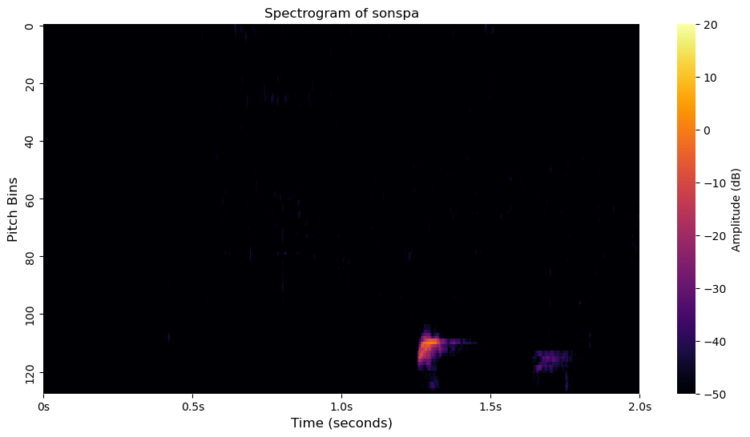

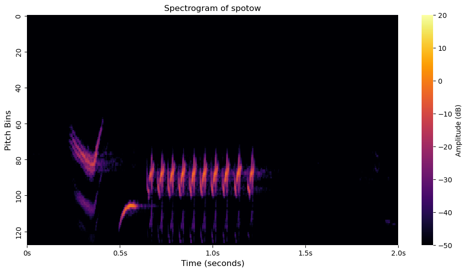

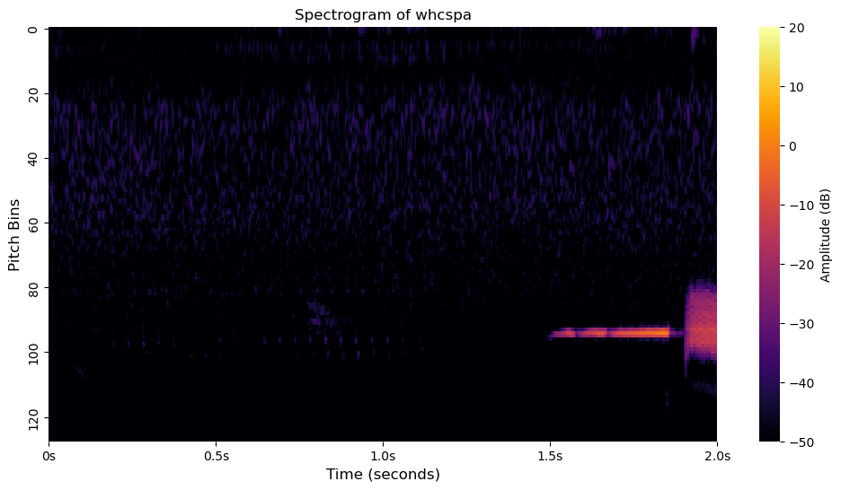

```python
# 4. Inspecting the Shape of Each Bird Species' Dataset in HDF5
fs = 22050

duration = 2.0
time_axis = np.linspace(0, duration, 517)  # 517 time steps

def plot_spectrogram(species_key):
    dataset = f[species_key][:]
    dataset = np.transpose(dataset, (2, 0, 1))  # Shape: (N, 128, 517)

    sample_spec = dataset[0]

    plt.figure(figsize=(12, 6))
    sns.heatmap(sample_spec, cmap='inferno', cbar_kws={'label': 'Amplitude (dB)'}, xticklabels=50, yticklabels=20, vmin=-50, vmax=20)
    plt.xticks(ticks=np.linspace(0, 517, 5), labels=["0s", "0.5s", "1.0s", "1.5s", "2.0s"])
    plt.title(f"Spectrogram of {species_key}")
    plt.xlabel("Time (seconds)", fontsize=12)
    plt.ylabel("Pitch Bins", fontsize=12)
    plt.savefig(f"spectrogram_{species_key}.png", dpi=300)
    plt.show()

# Plot for all 12 species
for key in bird_species:
    plot_spectrogram(key)
```

A dataset of 12 bird species was created, with each species stored as a 3D array representing spectrograms of samples, frequencies, and time steps.

# 2. Binary CNN Model with two bird species "amecro and amerob"

# 2.1 Binary CNN Model_1 "amecro and amerob"

```python
amecro_spectrograms = f['amecro'][:]
amerob_spectrograms = f['amerob'][:]

print("amerco shape:", amecro_spectrograms.shape)
print("amerob shape:", amerob_spectrograms.shape)
```

```
amerco shape: (128, 517, 66)
amerob shape: (128, 517, 172)
```

```python
# Prepare Data
species_list = ['amecro', 'amerob']

spectro_data = []
labels = []

for species_key in species_list:
    spectrograms = f[species_key][:]  # shape (128, 517, N)
    spectrograms = np.transpose(spectrograms, (2, 0, 1))  # (N, 128, 517)
    for spec in spectrograms:
        spectro_data.append(spec)
        labels.append(species_key)

# Normalize
spectro_data = np.array(spectro_data).astype('float32')
epsilon = 1e-8
spectro_data /= (np.max(spectro_data, axis=(1, 2), keepdims=True) + epsilon)

# Encode labels
encoder = LabelEncoder()
labels_encoded = encoder.fit_transform(labels)

# Train/test
X_train, X_test, y_train, y_test = train_test_split(
    spectro_data, labels_encoded, test_size=0.3, stratify=labels_encoded, random_state=42
)

# Add channel dimension
X_train = X_train[..., np.newaxis]
X_test = X_test[..., np.newaxis]
print("Before augmentation:", X_train.shape, y_train.shape)

# Augmentation
def augment_spectrogram(spectrogram):
    shifted = np.roll(spectrogram, shift=np.random.randint(-20, 20), axis=1)
    zoom_factor = np.random.uniform(0.9, 1.1)
    warped = scipy.ndimage.zoom(shifted, (zoom_factor, 1), order=1)

    # Ensure shape = (128, 517)
    if warped.shape[0] < 128:
        warped = np.pad(warped, ((0, 128 - warped.shape[0]), (0, 0)), mode='constant')
    elif warped.shape[0] > 128:
        warped = warped[:128, :]

    if warped.shape[1] < 517:
        warped = np.pad(warped, ((0, 0), (0, 517 - warped.shape[1])), mode='constant')
    elif warped.shape[1] > 517:
        warped = warped[:, :517]

    noisy = warped + np.random.normal(0, 0.03, warped.shape)
    return np.clip(noisy, 0.0, 1.0)

# Count samples per class
count_0 = np.sum(y_train == 0)
count_1 = np.sum(y_train == 1)

# Target: match the larger class
target_count = max(count_0, count_1)
needed = target_count - count_0

# Augment class 0 (amecro) to balance
amecro_aug = []
amecro_labels = []

amecro_indices = np.where(y_train == 0)[0]
num_aug_per_sample = (needed // len(amecro_indices)) + 1

for idx in amecro_indices:
    for _ in range(num_aug_per_sample):
        if len(amecro_aug) >= needed:
            break
        spec = X_train[idx, :, :, 0]
        aug = augment_spectrogram(spec)
        amecro_aug.append(aug[..., np.newaxis])
        amecro_labels.append(0)

# Augmented data
X_train = np.concatenate((X_train, np.array(amecro_aug)))
y_train = np.concatenate((y_train, np.array(amecro_labels)))
print("After augmentation:", X_train.shape, y_train.shape)

# Class weights
class_weights = class_weight.compute_class_weight(
    class_weight='balanced',
    classes=np.unique(y_train),
    y=y_train
)
class_weights_dict = dict(enumerate(class_weights))

# Class distribution
unique, counts = np.unique(y_train, return_counts=True)
class_distribution = {encoder.inverse_transform([u])[0]: c for u, c in zip(unique, counts)}
print("Training set class distribution:", dict(zip(unique, counts)))

print("Class weights:", class_weights_dict)
print("Class distribution:", class_distribution)
```

```
Before augmentation: (166, 128, 517, 1) (166,)
After augmentation: (240, 128, 517, 1) (240,)
Training set class distribution: {0: 120, 1: 120}
Class weights: {0: 1.0, 1: 1.0}
Class distribution: {'amecro': 120, 'amerob': 120}
```

```python
# Binary CNN Model 1
cnn_binary_model1 = Sequential([
    Input(shape=(128, 517, 1)),
    Conv2D(32, (3, 3), activation='relu'),
    MaxPooling2D((2, 2)),

    Conv2D(64, (3, 3), activation='relu'),
    MaxPooling2D((2, 2)),
    Flatten(),
    Dense(128, activation='relu'),
    Dense(1, activation='sigmoid')
])

# Compile
cnn_binary_model1.compile(optimizer='rmsprop', loss='binary_crossentropy', metrics=['accuracy'])
cnn_binary_model1.summary()

# Start timer
start_time = time.time()

# Train
history = cnn_binary_model1.fit(X_train, y_train, epochs=10, validation_data=(X_test, y_test), batch_size=32, class_weight=class_weights_dict)

# End timer
end_time = time.time()

# Evaluation
test_loss, test_accuracy = cnn_binary_model1.evaluate(X_test, y_test)
print("Accuracy Test Set:", test_accuracy)

train_score = cnn_binary_model1.evaluate(X_train, y_train, verbose=0)
print("Train Accuracy: {:.2f}%".format(train_score[1]*100))

test_score = cnn_binary_model1.evaluate(X_test, y_test, verbose=0)
print("Test Accuracy: {:.2f}%".format(test_score[1]*100))

elapsed_time = end_time - start_time
print(f"\n Training time of Binary CNN Model: {elapsed_time:.2f} seconds ({elapsed_time / 60:.2f} minutes)")
```

```
Model: "sequential"
```

```
┏━━━━━━━━━━━━━━━━━━━━━━━━━━━━━━━━━┳━━━━━━━━━━━━━━━━━━━━━━━━┳━━━━━━━━━━━━━━━┓
┃ Layer (type)                    ┃ Output Shape           ┃       Param # ┃
┡━━━━━━━━━━━━━━━━━━━━━━━━━━━━━━━━━╇━━━━━━━━━━━━━━━━━━━━━━━━╇━━━━━━━━━━━━━━━┩
│ conv2d (Conv2D)                 │ (None, 126, 515, 32)   │           320 │
├─────────────────────────────────┼────────────────────────┼───────────────┤
│ max_pooling2d (MaxPooling2D)    │ (None, 63, 257, 32)    │             0 │
├─────────────────────────────────┼────────────────────────┼───────────────┤
│ conv2d_1 (Conv2D)               │ (None, 61, 255, 64)    │        18,496 │
├─────────────────────────────────┼────────────────────────┼───────────────┤
│ max_pooling2d_1 (MaxPooling2D)  │ (None, 30, 127, 64)    │             0 │
├─────────────────────────────────┼────────────────────────┼───────────────┤
│ flatten (Flatten)               │ (None, 243840)         │             0 │
├─────────────────────────────────┼────────────────────────┼───────────────┤
│ dense (Dense)                   │ (None, 128)            │    31,211,648 │
├─────────────────────────────────┼────────────────────────┼───────────────┤
│ dense_1 (Dense)                 │ (None, 1)              │           129 │
└─────────────────────────────────┴────────────────────────┴───────────────┘
```

```
 Total params: 31,230,593 (119.14 MB)
```

```
 Trainable params: 31,230,593 (119.14 MB)
```

```
 Non-trainable params: 0 (0.00 B)
```

```
8/8 ━━━━━━━━━━━━━━━━━━━━ 4s 384ms/step - accuracy: 0.6301 - loss: 53717516288.0000 - val_accuracy: 0.7222 - val_loss: 890290624.0000
8/8 ━━━━━━━━━━━━━━━━━━━━ 3s 398ms/step - accuracy: 0.6938 - loss: 1005926848.0000 - val_accuracy: 0.3472 - val_loss: 1422371328.0000
8/8 ━━━━━━━━━━━━━━━━━━━━ 3s 377ms/step - accuracy: 0.6740 - loss: 501077088.0000 - val_accuracy: 0.7222 - val_loss: 99024272.0000
8/8 ━━━━━━━━━━━━━━━━━━━━ 3s 374ms/step - accuracy: 0.7250 - loss: 111810528.0000 - val_accuracy: 0.8056 - val_loss: 34470228.0000
8/8 ━━━━━━━━━━━━━━━━━━━━ 3s 425ms/step - accuracy: 0.9396 - loss: 2246251.2500 - val_accuracy: 0.7639 - val_loss: 42473596.0000
8/8 ━━━━━━━━━━━━━━━━━━━━ 5s 579ms/step - accuracy: 0.9531 - loss: 2056016.3750 - val_accuracy: 0.8333 - val_loss: 4806057.0000
8/8 ━━━━━━━━━━━━━━━━━━━━ 4s 560ms/step - accuracy: 0.9605 - loss: 426773.7188 - val_accuracy: 0.8333 - val_loss: 7535651.5000
8/8 ━━━━━━━━━━━━━━━━━━━━ 4s 516ms/step - accuracy: 0.9686 - loss: 312681.1875 - val_accuracy: 0.8194 - val_loss: 8712229.0000
8/8 ━━━━━━━━━━━━━━━━━━━━ 4s 507ms/step - accuracy: 0.9712 - loss: 437899.0625 - val_accuracy: 0.8056 - val_loss: 6670240.5000
8/8 ━━━━━━━━━━━━━━━━━━━━ 4s 513ms/step - accuracy: 0.9573 - loss: 553817.7500 - val_accuracy: 0.8472 - val_loss: 14142937.0000
3/3 ━━━━━━━━━━━━━━━━━━━━ 0s 101ms/step - accuracy: 0.8533 - loss: 17736628.0000
Accuracy Test Set: 0.8472222089767456
Train Accuracy: 98.33%
Test Accuracy: 84.72%

 Training time of Binary CNN Model: 37.99 seconds (0.63 minutes)
```

Result: Train Accuracy: 98.33% Test Accuracy: 84.72%

This CNN model learned the training data very well, achieving 98.33% accuracy. However, its test accuracy was lower at 84.72%, which suggests the model may be overfitting to the training data.

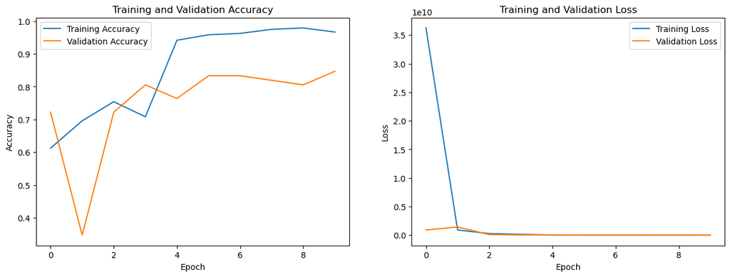

```python
# Plot of Training and Validation Accuracy
plt.figure(figsize=(15, 5))

plt.subplot(1, 2, 1)
plt.plot(history.history['accuracy'], label='Training Accuracy')
plt.plot(history.history['val_accuracy'], label='Validation Accuracy')
plt.title('Training and Validation Accuracy')
plt.xlabel('Epoch')
plt.ylabel('Accuracy')
plt.legend()

# Plot of Training and Validation Loss
plt.subplot(1, 2, 2)
plt.plot(history.history['loss'], label='Training Loss')
plt.plot(history.history['val_loss'], label='Validation Loss')
plt.title('Training and Validation Loss')
plt.xlabel('Epoch')
plt.ylabel('Loss')
plt.legend()

plt.show()
```

Result: These plots show strong learning on the training data, reaching near-perfect accuracy with very low training loss. However, the validation accuracy is noticeably lower and fluctuates across epochs, while validation loss remains steady. This suggests that the model may be overfitting—performing well on the training set but not generalizing as well to new data.

```
3/3 ━━━━━━━━━━━━━━━━━━━━ 0s 84ms/step
```

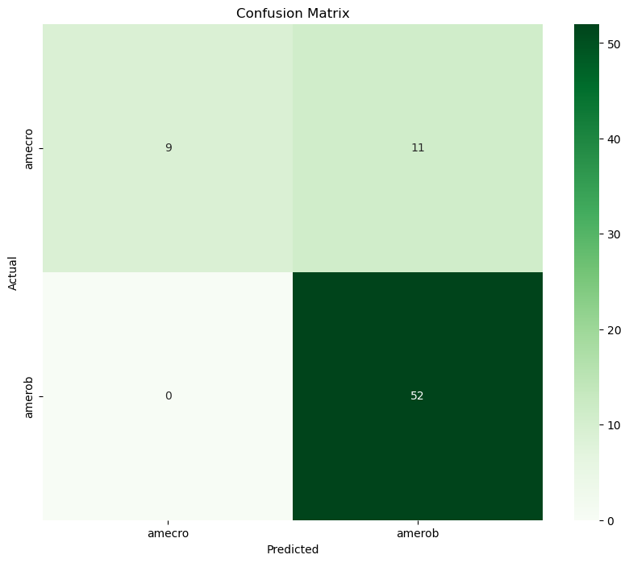

```
              precision    recall  f1-score   support

      amecro       1.00      0.45      0.62        20
      amerob       0.83      1.00      0.90        52

    accuracy                           0.85        72
   macro avg       0.91      0.72      0.76        72
weighted avg       0.87      0.85      0.83        72
```

```python
# Confusion Matrix

# Predict
y_pred = cnn_binary_model1.predict(X_test)
y_pred = (y_pred > 0.5).astype(int).flatten()

# Define label names for binary case
label_names = encoder.inverse_transform([0, 1])

# Confusion matrix
conf_matrix1 = confusion_matrix(y_test, y_pred)

plt.figure(figsize=(10, 8))
sns.heatmap(conf_matrix1, annot=True, fmt='d', cmap='Greens',
            xticklabels=label_names, yticklabels=label_names)
plt.xlabel('Predicted')
plt.ylabel('Actual')
plt.title('Confusion Matrix')
plt.show()

# Classification report
print(classification_report(y_test, y_pred, target_names=label_names, zero_division=0))
```

Result: This confusion matrix shows that the model is very good at detecting amerob, with a recall of 100%, while it detects amecro with 45% recall, meaning many amecro cases are misclassified. However, the model still achieves a high overall accuracy of 85% and has balanced weighted performance metrics.

Now we build a CNN binary model 2 to fix overfitting and improve the performance of the first model.

# 2.2 Binary CNN Model_2

```python
# Binary CNN Model 2
cnn_binary_model2 = Sequential([
    Input(shape=(128, 517, 1)),

    Conv2D(32, (3, 3), activation='relu'),
    BatchNormalization(),
    MaxPooling2D((2, 2)),

    Conv2D(64, (3, 3), activation='relu'),
    BatchNormalization(),
    MaxPooling2D((2, 2)),

    Conv2D(128, (3, 3), activation='relu'),
    BatchNormalization(),
    MaxPooling2D((2, 2)),
    Flatten(),
    Dropout(0.5),
    Dense(128, activation='relu'),
    Dropout(0.3),
    Dense(1, activation='sigmoid')
])

# Compile the model
cnn_binary_model2.compile(optimizer='adam', loss='binary_crossentropy', metrics=['accuracy'])
cnn_binary_model2.summary()

# Start Time
start_time = time.time()

# Train
history = cnn_binary_model2.fit(X_train, y_train, epochs=30, validation_data=(X_test, y_test), batch_size=64, class_weight=class_weights_dict)

# End time
end_time = time.time()

# Evaluation
test_loss, test_accuracy = cnn_binary_model2.evaluate(X_test, y_test)
print("Accuracy Test Set:", test_accuracy)

train_score = cnn_binary_model2.evaluate(X_train, y_train, verbose=0)
print("Train Accuracy: {:.2f}%".format(train_score[1]*100))

test_score = cnn_binary_model2.evaluate(X_test, y_test, verbose=0)
print("Test Accuracy: {:.2f}%".format(test_score[1]*100))

elapsed_time = end_time - start_time
print(f"\nTraining time of Binary CNN Model 2: {elapsed_time:.2f} seconds ({elapsed_time / 60:.2f} minutes)")
```

```
Model: "sequential_5"
```

```
┏━━━━━━━━━━━━━━━━━━━━━━━━━━━━━━━━━┳━━━━━━━━━━━━━━━━━━━━━━━━┳━━━━━━━━━━━━━━━┓
┃ Layer (type)                    ┃ Output Shape           ┃       Param # ┃
┡━━━━━━━━━━━━━━━━━━━━━━━━━━━━━━━━━╇━━━━━━━━━━━━━━━━━━━━━━━━╇━━━━━━━━━━━━━━━┩
│ conv2d_12 (Conv2D)              │ (None, 126, 515, 32)   │           320 │
├─────────────────────────────────┼────────────────────────┼───────────────┤
│ batch_normalization_7           │ (None, 126, 515, 32)   │           128 │
│ (BatchNormalization)            │                        │               │
├─────────────────────────────────┼────────────────────────┼───────────────┤
│ max_pooling2d_12 (MaxPooling2D) │ (None, 63, 257, 32)    │             0 │
├─────────────────────────────────┼────────────────────────┼───────────────┤
│ conv2d_13 (Conv2D)              │ (None, 61, 255, 64)    │        18,496 │
├─────────────────────────────────┼────────────────────────┼───────────────┤
│ batch_normalization_8           │ (None, 61, 255, 64)    │           256 │
│ (BatchNormalization)            │                        │               │
├─────────────────────────────────┼────────────────────────┼───────────────┤
│ max_pooling2d_13 (MaxPooling2D) │ (None, 30, 127, 64)    │             0 │
├─────────────────────────────────┼────────────────────────┼───────────────┤
│ conv2d_14 (Conv2D)              │ (None, 28, 125, 128)   │        73,856 │
├─────────────────────────────────┼────────────────────────┼───────────────┤
│ batch_normalization_9           │ (None, 28, 125, 128)   │           512 │
│ (BatchNormalization)            │                        │               │
├─────────────────────────────────┼────────────────────────┼───────────────┤
│ max_pooling2d_14 (MaxPooling2D) │ (None, 14, 62, 128)    │             0 │
├─────────────────────────────────┼────────────────────────┼───────────────┤
│ flatten_5 (Flatten)             │ (None, 111104)         │             0 │
├─────────────────────────────────┼────────────────────────┼───────────────┤
│ dropout_10 (Dropout)            │ (None, 111104)         │             0 │
├─────────────────────────────────┼────────────────────────┼───────────────┤
│ dense_10 (Dense)                │ (None, 128)            │    14,221,440 │
├─────────────────────────────────┼────────────────────────┼───────────────┤
│ dropout_11 (Dropout)            │ (None, 128)            │             0 │
├─────────────────────────────────┼────────────────────────┼───────────────┤
│ dense_11 (Dense)                │ (None, 1)              │           129 │
└─────────────────────────────────┴────────────────────────┴───────────────┘
```

```
 Total params: 14,315,137 (54.61 MB)
```

```
 Trainable params: 14,314,689 (54.61 MB)
```

```
 Non-trainable params: 448 (1.75 KB)
```

```
4/4 ━━━━━━━━━━━━━━━━━━━━ 9s 2s/step - accuracy: 0.5944 - loss: 28.0967 - val_accuracy: 0.7222 - val_loss: 169.3231
4/4 ━━━━━━━━━━━━━━━━━━━━ 7s 2s/step - accuracy: 0.7304 - loss: 12.3834 - val_accuracy: 0.6944 - val_loss: 307.3927
4/4 ━━━━━━━━━━━━━━━━━━━━ 7s 2s/step - accuracy: 0.8267 - loss: 10.5804 - val_accuracy: 0.7222 - val_loss: 289.9437
4/4 ━━━━━━━━━━━━━━━━━━━━ 7s 2s/step - accuracy: 0.8577 - loss: 6.0207 - val_accuracy: 0.7361 - val_loss: 255.0692
4/4 ━━━━━━━━━━━━━━━━━━━━ 8s 2s/step - accuracy: 0.8649 - loss: 2.0720 - val_accuracy: 0.7222 - val_loss: 198.1086
4/4 ━━━━━━━━━━━━━━━━━━━━ 10s 3s/step - accuracy: 0.8875 - loss: 0.7720 - val_accuracy: 0.7222 - val_loss: 142.0576
4/4 ━━━━━━━━━━━━━━━━━━━━ 10s 2s/step - accuracy: 0.8780 - loss: 0.7660 - val_accuracy: 0.7361 - val_loss: 116.5202
4/4 ━━━━━━━━━━━━━━━━━━━━ 9s 2s/step - accuracy: 0.9221 - loss: 0.4919 - val_accuracy: 0.7222 - val_loss: 107.8941
4/4 ━━━━━━━━━━━━━━━━━━━━ 9s 2s/step - accuracy: 0.9365 - loss: 0.2012 - val_accuracy: 0.7361 - val_loss: 99.0380
4/4 ━━━━━━━━━━━━━━━━━━━━ 10s 2s/step - accuracy: 0.9331 - loss: 0.2222 - val_accuracy: 0.7361 - val_loss: 90.7738
4/4 ━━━━━━━━━━━━━━━━━━━━ 9s 2s/step - accuracy: 0.9298 - loss: 0.4128 - val_accuracy: 0.7222 - val_loss: 81.2616
4/4 ━━━━━━━━━━━━━━━━━━━━ 10s 2s/step - accuracy: 0.9405 - loss: 0.1769 - val_accuracy: 0.7500 - val_loss: 70.6029
4/4 ━━━━━━━━━━━━━━━━━━━━ 10s 2s/step - accuracy: 0.9422 - loss: 0.2842 - val_accuracy: 0.7500 - val_loss: 62.7621
4/4 ━━━━━━━━━━━━━━━━━━━━ 10s 2s/step - accuracy: 0.9304 - loss: 0.3108 - val_accuracy: 0.7083 - val_loss: 56.7604
4/4 ━━━━━━━━━━━━━━━━━━━━ 10s 2s/step - accuracy: 0.9271 - loss: 0.2227 - val_accuracy: 0.7083 - val_loss: 51.6625
4/4 ━━━━━━━━━━━━━━━━━━━━ 9s 2s/step - accuracy: 0.9389 - loss: 0.1928 - val_accuracy: 0.7083 - val_loss: 47.5328
4/4 ━━━━━━━━━━━━━━━━━━━━ 10s 2s/step - accuracy: 0.9352 - loss: 0.2217 - val_accuracy: 0.7083 - val_loss: 45.3992
4/4 ━━━━━━━━━━━━━━━━━━━━ 9s 2s/step - accuracy: 0.9422 - loss: 0.2042 - val_accuracy: 0.7222 - val_loss: 43.7241
4/4 ━━━━━━━━━━━━━━━━━━━━ 10s 2s/step - accuracy: 0.9287 - loss: 0.2034 - val_accuracy: 0.7222 - val_loss: 41.6952
4/4 ━━━━━━━━━━━━━━━━━━━━ 12s 3s/step - accuracy: 0.9432 - loss: 0.2075 - val_accuracy: 0.7222 - val_loss: 39.3912
4/4 ━━━━━━━━━━━━━━━━━━━━ 62s 13s/step - accuracy: 0.9351 - loss: 0.2027 - val_accuracy: 0.7500 - val_loss: 37.3252
4/4 ━━━━━━━━━━━━━━━━━━━━ 11s 3s/step - accuracy: 0.9348 - loss: 0.1983 - val_accuracy: 0.7361 - val_loss: 35.5474
4/4 ━━━━━━━━━━━━━━━━━━━━ 12s 3s/step - accuracy: 0.9389 - loss: 0.1975 - val_accuracy: 0.7500 - val_loss: 33.8869
4/4 ━━━━━━━━━━━━━━━━━━━━ 10s 3s/step - accuracy: 0.9405 - loss: 0.1876 - val_accuracy: 0.7500 - val_loss: 32.2727
4/4 ━━━━━━━━━━━━━━━━━━━━ 10s 3s/step - accuracy: 0.9405 - loss: 0.1991 - val_accuracy: 0.7639 - val_loss: 30.9831
4/4 ━━━━━━━━━━━━━━━━━━━━ 10s 2s/step - accuracy: 0.9422 - loss: 0.1619 - val_accuracy: 0.7778 - val_loss: 29.8268
4/4 ━━━━━━━━━━━━━━━━━━━━ 10s 2s/step - accuracy: 0.9321 - loss: 0.2400 - val_accuracy: 0.7222 - val_loss: 32.2513
4/4 ━━━━━━━━━━━━━━━━━━━━ 10s 2s/step - accuracy: 0.9363 - loss: 0.6439 - val_accuracy: 0.7222 - val_loss: 27.9435
4/4 ━━━━━━━━━━━━━━━━━━━━ 9s 2s/step - accuracy: 0.9432 - loss: 0.1768 - val_accuracy: 0.8056 - val_loss: 26.0399
4/4 ━━━━━━━━━━━━━━━━━━━━ 9s 2s/step - accuracy: 0.9423 - loss: 0.1552 - val_accuracy: 0.8194 - val_loss: 26.1454
3/3 ━━━━━━━━━━━━━━━━━━━━ 1s 129ms/step - accuracy: 0.8160 - loss: 33.3475
Accuracy Test Set: 0.8194444179534912
Train Accuracy: 93.75%
Test Accuracy: 81.94%

Training time of Binary CNN Model 2: 336.08 seconds (5.60 minutes)
```

Result: The CNN binary model achieved a training accuracy of 93.75% and a good test accuracy of 82%, indicating effective learning and good generalization. Although there is a small overfitting gap, the use of dropout and the Adam optimizer helped maintain solid test performance.

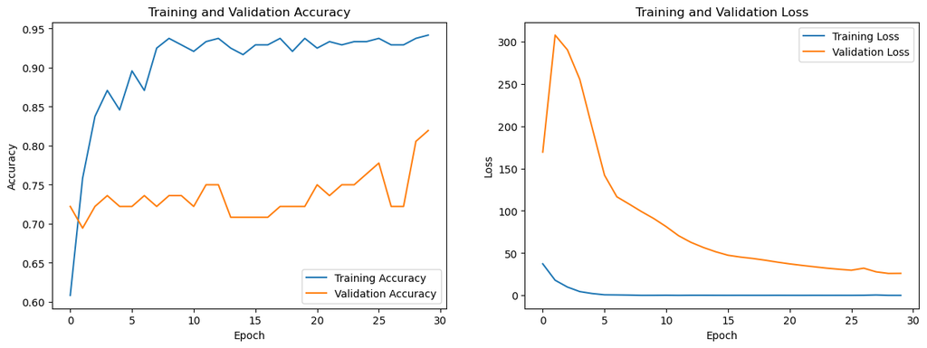

```python
# Plot of Training and Validation Accuracy
plt.figure(figsize=(15, 5))

plt.subplot(1, 2, 1)
plt.plot(history.history['accuracy'], label='Training Accuracy')
plt.plot(history.history['val_accuracy'], label='Validation Accuracy')
plt.title('Training and Validation Accuracy')
plt.xlabel('Epoch')
plt.ylabel('Accuracy')
plt.legend()

# Plot of Training and Validation Loss
plt.subplot(1, 2, 2)
plt.plot(history.history['loss'], label='Training Loss')
plt.plot(history.history['val_loss'], label='Validation Loss')
plt.title('Training and Validation Loss')
plt.xlabel('Epoch')
plt.ylabel('Loss')
plt.legend()

plt.show()
```

```
3/3 ━━━━━━━━━━━━━━━━━━━━ 0s 116ms/step
```

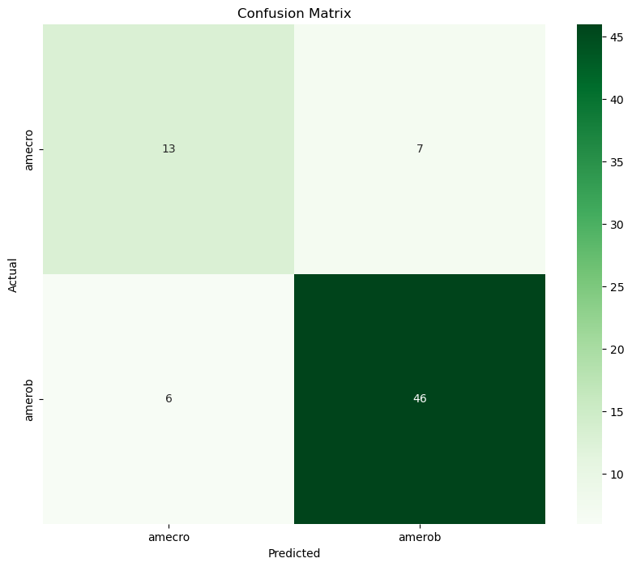

```
              precision    recall  f1-score   support

      amecro       0.68      0.65      0.67        20
      amerob       0.87      0.88      0.88        52

    accuracy                           0.82        72
   macro avg       0.78      0.77      0.77        72
weighted avg       0.82      0.82      0.82        72
```

```python
# Confusion matrix

# Predictions
y_pred = cnn_binary_model2.predict(X_test)
y_pred = (y_pred > 0.5).astype(int).flatten()

# Get class names used in binary model
label_names = encoder.inverse_transform([0, 1])  # ['amecro', 'amerob']

# Confusion matrix
conf_matrix2 = confusion_matrix(y_test, y_pred)

# Plot
plt.figure(figsize=(10, 8))
sns.heatmap(conf_matrix2, annot=True, fmt='d', cmap='Greens',
            xticklabels=label_names, yticklabels=label_names)
plt.xlabel('Predicted')
plt.ylabel('Actual')
plt.title('Confusion Matrix')
plt.show()

# Classification report
print(classification_report(y_test, y_pred, target_names=label_names, zero_division=0))
```

Result: This CNN model achieved a test accuracy of 82% and performed in identifying the class amerob, with a recall of 88% and an F1-score of 88%. While performance on the class amecro improved, the model still showed weaker generalization to this class, with a recall of 65% and an F1-score of 67%. Despite using balanced data and class weighting, this performance gap suggests that amecro may exhibit more complex or less distinctive patterns in its spectrograms, requiring further refinement or targeted augmentation to improve model sensitivity.

# 2.3 Tuned Binary CNN Model_3

```python
# Tuned Binary CNN Model
cnn_binary_model3 = Sequential([
    Input(shape=(128, 517, 1)),
    Conv2D(32, (3, 3), activation='relu', kernel_regularizer=l2(0.001)),
    BatchNormalization(),
    MaxPooling2D((2, 2)),

    Conv2D(64, (3, 3), activation='relu', kernel_regularizer=l2(0.001)),
    BatchNormalization(),
    MaxPooling2D((2, 2)),

    Conv2D(128, (3, 3), activation='relu', kernel_regularizer=l2(0.001)),
    BatchNormalization(),
    MaxPooling2D((2, 2)),
    Flatten(),
    Dropout(0.6),
    Dense(128, activation='relu', kernel_regularizer=l2(0.001)),
    Dense(1, activation='sigmoid')
])

# Compile
cnn_binary_model3.compile(optimizer='adam', loss='binary_crossentropy', metrics=['accuracy'])
cnn_binary_model3.summary()

# Early Stopping
early_stop = EarlyStopping(monitor='val_loss', patience=5, restore_best_weights=True)

# Start Time
start_time = time.time()

# Compile
history = cnn_binary_model3.fit(X_train, y_train, epochs=100, validation_data=(X_test, y_test), batch_size=32, callbacks=[early_stop])

# End time
end_time = time.time()

# Evaluate
test_loss, test_accuracy = cnn_binary_model3.evaluate(X_test, y_test)
print("Accuracy on test set:", test_accuracy)

train_score = cnn_binary_model3.evaluate(X_train, y_train, verbose=0)
print("Train Accuracy: {:.2f}%".format(train_score[1] * 100))

test_score = cnn_binary_model3.evaluate(X_test, y_test, verbose=0)
print("Test Accuracy: {:.2f}%".format(test_score[1] * 100))

elapsed_time = end_time - start_time
print(f"\nTraining time: {elapsed_time:.2f} seconds ({elapsed_time / 60:.2f} minutes)")
```

```
Model: "sequential_13"
```

```
┏━━━━━━━━━━━━━━━━━━━━━━━━━━━━━━━━━┳━━━━━━━━━━━━━━━━━━━━━━━━┳━━━━━━━━━━━━━━━┓
┃ Layer (type)                    ┃ Output Shape           ┃       Param # ┃
┡━━━━━━━━━━━━━━━━━━━━━━━━━━━━━━━━━╇━━━━━━━━━━━━━━━━━━━━━━━━╇━━━━━━━━━━━━━━━┩
│ conv2d_39 (Conv2D)              │ (None, 126, 515, 32)   │           320 │
├─────────────────────────────────┼────────────────────────┼───────────────┤
│ batch_normalization_39          │ (None, 126, 515, 32)   │           128 │
│ (BatchNormalization)            │                        │               │
├─────────────────────────────────┼────────────────────────┼───────────────┤
│ max_pooling2d_39 (MaxPooling2D) │ (None, 63, 257, 32)    │             0 │
├─────────────────────────────────┼────────────────────────┼───────────────┤
│ conv2d_40 (Conv2D)              │ (None, 61, 255, 64)    │        18,496 │
├─────────────────────────────────┼────────────────────────┼───────────────┤
│ batch_normalization_40          │ (None, 61, 255, 64)    │           256 │
│ (BatchNormalization)            │                        │               │
├─────────────────────────────────┼────────────────────────┼───────────────┤
│ max_pooling2d_40 (MaxPooling2D) │ (None, 30, 127, 64)    │             0 │
├─────────────────────────────────┼────────────────────────┼───────────────┤
│ conv2d_41 (Conv2D)              │ (None, 28, 125, 128)   │        73,856 │
├─────────────────────────────────┼────────────────────────┼───────────────┤
│ batch_normalization_41          │ (None, 28, 125, 128)   │           512 │
│ (BatchNormalization)            │                        │               │
├─────────────────────────────────┼────────────────────────┼───────────────┤
│ max_pooling2d_41 (MaxPooling2D) │ (None, 14, 62, 128)    │             0 │
├─────────────────────────────────┼────────────────────────┼───────────────┤
│ flatten_13 (Flatten)            │ (None, 111104)         │             0 │
├─────────────────────────────────┼────────────────────────┼───────────────┤
│ dropout_13 (Dropout)            │ (None, 111104)         │             0 │
├─────────────────────────────────┼────────────────────────┼───────────────┤
│ dense_26 (Dense)                │ (None, 128)            │    14,221,440 │
├─────────────────────────────────┼────────────────────────┼───────────────┤
│ dense_27 (Dense)                │ (None, 1)              │           129 │
└─────────────────────────────────┴────────────────────────┴───────────────┘
```

```
 Total params: 14,315,137 (54.61 MB)
```

```
 Trainable params: 14,314,689 (54.61 MB)
```

```
 Non-trainable params: 448 (1.75 KB)
```

```
8/8 ━━━━━━━━━━━━━━━━━━━━ 11s 1s/step - accuracy: 0.6937 - loss: 17.3304 - val_accuracy: 0.7083 - val_loss: 497.4086
8/8 ━━━━━━━━━━━━━━━━━━━━ 8s 1s/step - accuracy: 0.8489 - loss: 2.8036 - val_accuracy: 0.6944 - val_loss: 635.6686
8/8 ━━━━━━━━━━━━━━━━━━━━ 8s 993ms/step - accuracy: 0.8896 - loss: 1.2664 - val_accuracy: 0.7778 - val_loss: 320.4224
8/8 ━━━━━━━━━━━━━━━━━━━━ 10s 1s/step - accuracy: 0.9313 - loss: 1.6455 - val_accuracy: 0.7222 - val_loss: 340.4230
8/8 ━━━━━━━━━━━━━━━━━━━━ 10s 1s/step - accuracy: 0.9434 - loss: 1.3279 - val_accuracy: 0.7639 - val_loss: 255.3085
8/8 ━━━━━━━━━━━━━━━━━━━━ 10s 1s/step - accuracy: 0.9447 - loss: 0.9672 - val_accuracy: 0.7778 - val_loss: 214.0525
8/8 ━━━━━━━━━━━━━━━━━━━━ 11s 1s/step - accuracy: 0.9467 - loss: 0.9827 - val_accuracy: 0.7778 - val_loss: 207.2291
8/8 ━━━━━━━━━━━━━━━━━━━━ 10s 1s/step - accuracy: 0.9451 - loss: 1.4386 - val_accuracy: 0.7083 - val_loss: 276.1461
8/8 ━━━━━━━━━━━━━━━━━━━━ 10s 1s/step - accuracy: 0.9386 - loss: 1.5477 - val_accuracy: 0.7639 - val_loss: 226.7190
8/8 ━━━━━━━━━━━━━━━━━━━━ 11s 1s/step - accuracy: 0.9301 - loss: 1.3020 - val_accuracy: 0.7917 - val_loss: 175.0603
8/8 ━━━━━━━━━━━━━━━━━━━━ 10s 1s/step - accuracy: 0.9454 - loss: 1.0880 - val_accuracy: 0.7500 - val_loss: 170.2850
8/8 ━━━━━━━━━━━━━━━━━━━━ 10s 1s/step - accuracy: 0.9376 - loss: 1.0022 - val_accuracy: 0.7639 - val_loss: 182.6192
8/8 ━━━━━━━━━━━━━━━━━━━━ 11s 1s/step - accuracy: 0.9263 - loss: 1.0541 - val_accuracy: 0.7639 - val_loss: 178.1844
8/8 ━━━━━━━━━━━━━━━━━━━━ 11s 1s/step - accuracy: 0.9362 - loss: 0.9855 - val_accuracy: 0.7778 - val_loss: 168.7365
8/8 ━━━━━━━━━━━━━━━━━━━━ 11s 1s/step - accuracy: 0.9248 - loss: 1.0991 - val_accuracy: 0.7500 - val_loss: 186.0184
8/8 ━━━━━━━━━━━━━━━━━━━━ 10s 1s/step - accuracy: 0.9219 - loss: 1.3270 - val_accuracy: 0.7500 - val_loss: 175.2378
8/8 ━━━━━━━━━━━━━━━━━━━━ 10s 1s/step - accuracy: 0.9402 - loss: 0.9658 - val_accuracy: 0.7500 - val_loss: 167.4724
8/8 ━━━━━━━━━━━━━━━━━━━━ 10s 1s/step - accuracy: 0.9501 - loss: 0.9576 - val_accuracy: 0.7500 - val_loss: 162.3977
8/8 ━━━━━━━━━━━━━━━━━━━━ 11s 1s/step - accuracy: 0.9474 - loss: 0.9523 - val_accuracy: 0.7500 - val_loss: 156.6015
8/8 ━━━━━━━━━━━━━━━━━━━━ 11s 1s/step - accuracy: 0.9501 - loss: 0.9584 - val_accuracy: 0.7500 - val_loss: 152.1177
8/8 ━━━━━━━━━━━━━━━━━━━━ 10s 1s/step - accuracy: 0.9501 - loss: 0.9454 - val_accuracy: 0.7361 - val_loss: 148.9535
8/8 ━━━━━━━━━━━━━━━━━━━━ 11s 1s/step - accuracy: 0.9474 - loss: 0.9240 - val_accuracy: 0.7361 - val_loss: 144.8863
8/8 ━━━━━━━━━━━━━━━━━━━━ 10s 1s/step - accuracy: 0.9501 - loss: 0.9127 - val_accuracy: 0.7361 - val_loss: 142.0488
8/8 ━━━━━━━━━━━━━━━━━━━━ 11s 1s/step - accuracy: 0.9501 - loss: 0.8968 - val_accuracy: 0.7500 - val_loss: 139.4656
8/8 ━━━━━━━━━━━━━━━━━━━━ 11s 1s/step - accuracy: 0.9501 - loss: 0.8846 - val_accuracy: 0.7361 - val_loss: 137.7242
8/8 ━━━━━━━━━━━━━━━━━━━━ 11s 1s/step - accuracy: 0.9501 - loss: 0.8762 - val_accuracy: 0.7361 - val_loss: 135.9532
8/8 ━━━━━━━━━━━━━━━━━━━━ 11s 1s/step - accuracy: 0.9501 - loss: 0.8606 - val_accuracy: 0.7500 - val_loss: 134.5045
8/8 ━━━━━━━━━━━━━━━━━━━━ 11s 1s/step - accuracy: 0.9501 - loss: 0.8514 - val_accuracy: 0.7500 - val_loss: 132.8712
8/8 ━━━━━━━━━━━━━━━━━━━━ 10s 1s/step - accuracy: 0.9501 - loss: 0.8423 - val_accuracy: 0.7500 - val_loss: 130.9145
8/8 ━━━━━━━━━━━━━━━━━━━━ 12s 1s/step - accuracy: 0.9501 - loss: 0.8269 - val_accuracy: 0.7361 - val_loss: 129.4497
8/8 ━━━━━━━━━━━━━━━━━━━━ 11s 1s/step - accuracy: 0.9501 - loss: 0.8201 - val_accuracy: 0.7361 - val_loss: 128.4271
8/8 ━━━━━━━━━━━━━━━━━━━━ 11s 1s/step - accuracy: 0.9501 - loss: 0.8106 - val_accuracy: 0.7361 - val_loss: 127.8398
8/8 ━━━━━━━━━━━━━━━━━━━━ 10s 1s/step - accuracy: 0.9501 - loss: 0.8007 - val_accuracy: 0.7361 - val_loss: 126.8424
8/8 ━━━━━━━━━━━━━━━━━━━━ 10s 1s/step - accuracy: 0.9501 - loss: 0.7876 - val_accuracy: 0.7361 - val_loss: 125.1129
8/8 ━━━━━━━━━━━━━━━━━━━━ 10s 1s/step - accuracy: 0.9501 - loss: 0.7777 - val_accuracy: 0.7361 - val_loss: 123.9219
8/8 ━━━━━━━━━━━━━━━━━━━━ 10s 1s/step - accuracy: 0.9501 - loss: 0.7727 - val_accuracy: 0.7361 - val_loss: 122.3689
8/8 ━━━━━━━━━━━━━━━━━━━━ 10s 1s/step - accuracy: 0.9529 - loss: 0.7751 - val_accuracy: 0.7361 - val_loss: 121.3730
8/8 ━━━━━━━━━━━━━━━━━━━━ 10s 1s/step - accuracy: 0.9529 - loss: 0.7672 - val_accuracy: 0.7361 - val_loss: 120.6477
8/8 ━━━━━━━━━━━━━━━━━━━━ 10s 1s/step - accuracy: 0.9501 - loss: 0.7579 - val_accuracy: 0.7500 - val_loss: 118.2942
8/8 ━━━━━━━━━━━━━━━━━━━━ 10s 1s/step - accuracy: 0.9600 - loss: 0.7623 - val_accuracy: 0.7500 - val_loss: 115.5494
```

[output cut: 10 more lines]

```
8/8 ━━━━━━━━━━━━━━━━━━━━ 10s 1s/step - accuracy: 0.9528 - loss: 0.6745 - val_accuracy: 0.7500 - val_loss: 106.0498
8/8 ━━━━━━━━━━━━━━━━━━━━ 10s 1s/step - accuracy: 0.9515 - loss: 0.7077 - val_accuracy: 0.7222 - val_loss: 97.6176
8/8 ━━━━━━━━━━━━━━━━━━━━ 10s 1s/step - accuracy: 0.9454 - loss: 0.7713 - val_accuracy: 0.7222 - val_loss: 93.5738
8/8 ━━━━━━━━━━━━━━━━━━━━ 11s 1s/step - accuracy: 0.9569 - loss: 1.2651 - val_accuracy: 0.7500 - val_loss: 66.5185
8/8 ━━━━━━━━━━━━━━━━━━━━ 17s 865ms/step - accuracy: 0.9202 - loss: 1.6976 - val_accuracy: 0.7361 - val_loss: 137.2331
8/8 ━━━━━━━━━━━━━━━━━━━━ 7s 901ms/step - accuracy: 0.9287 - loss: 2.4646 - val_accuracy: 0.7500 - val_loss: 331.1521
8/8 ━━━━━━━━━━━━━━━━━━━━ 10s 1s/step - accuracy: 0.8857 - loss: 5.2552 - val_accuracy: 0.6806 - val_loss: 244.7487
8/8 ━━━━━━━━━━━━━━━━━━━━ 11s 1s/step - accuracy: 0.8980 - loss: 5.5236 - val_accuracy: 0.7361 - val_loss: 360.4372
8/8 ━━━━━━━━━━━━━━━━━━━━ 11s 1s/step - accuracy: 0.8088 - loss: 18.2524 - val_accuracy: 0.6667 - val_loss: 804.3755
3/3 ━━━━━━━━━━━━━━━━━━━━ 1s 148ms/step - accuracy: 0.7344 - loss: 83.7595
Accuracy on test set: 0.75
Train Accuracy: 92.50%
Test Accuracy: 75.00%

Training time: 613.61 seconds (10.23 minutes)
```

[figure not shown]

```python
# Plot of Training and Validation Accuracy
plt.figure(figsize=(12, 5))

plt.subplot(1, 2, 1)
plt.plot(history.history['accuracy'], label='Training Accuracy')
plt.plot(history.history['val_accuracy'], label='Validation Accuracy')
plt.title('Training and Validation Accuracy')
plt.xlabel('Epoch')
plt.ylabel('Accuracy')
plt.legend()

# Plot of Training and Validation Loss
plt.subplot(1, 2, 2)
plt.plot(history.history['loss'], label='Training Loss')
plt.plot(history.history['val_loss'], label='Validation Loss')
plt.title('Training and Validation Loss')
plt.xlabel('Epoch')
plt.ylabel('Loss')
plt.legend()

plt.show()
```

```
3/3 ━━━━━━━━━━━━━━━━━━━━ 1s 252ms/step
```

[figure not shown]

[output not shown]

```python
# Confusion matrix

# Predictions
y_pred = cnn_binary_model3.predict(X_test)
y_pred = (y_pred > 0.5).astype(int).flatten()

# Get class names used in binary model
label_names = encoder.inverse_transform([0, 1])  # ['amecro', 'amerob']

# Confusion matrix
conf_matrix3 = confusion_matrix(y_test, y_pred)

# Plot
plt.figure(figsize=(10, 8))
sns.heatmap(conf_matrix3, annot=True, fmt='d', cmap='Greens',
            xticklabels=label_names, yticklabels=label_names)
plt.xlabel('Predicted')
plt.ylabel('Actual')
plt.title('Confusion Matrix')
plt.show()

# Classification report
print(classification_report(y_test, y_pred, target_names=label_names, zero_division=0))
```

Result: The tuned binary CNN model achieved an overall accuracy of 85% and demonstrated balanced precision across both classes. It performed strongly in identifying the majority class amerob, with a recall of 96% and an F1-score of 90%. However, the model struggled to detect the minority class amecro, with a lower recall of 55% and F1-score of 67%.

# 3. Multi-class CNN Model

# 3.1 Multi-class CNN Model_1 with all 12 bird species

```python
# Species with 12 bird
bird_species = ['amecro', 'amerob', 'bewwre', 'bkcchi', 'daejun', 'houfin',
                'houspa', 'norfli', 'rewbla', 'sonspa', 'spotow', 'whcspa']

spectrogram_data = []
labels = []

for species_key in bird_species:
    spectrograms = f[species_key][:]  # shape: (128, 517, N)
    spectrograms = np.transpose(spectrograms, (2, 0, 1))  # (N, 128, 517)

    for spectrogram in spectrograms[:30]:
        resized = resize(spectrogram, (256, 343), mode='constant', anti_aliasing=True)
        spectrogram_data.append(resized)
        labels.append(species_key)

# Convert to array and normalize
X = np.array(spectrogram_data).astype('float32')
X = X / (np.max(X) + 1e-8)
X = X[..., np.newaxis]  # Shape: (N, 256, 343, 1)

# Encode labels
encoder = LabelEncoder()
y_encoded = encoder.fit_transform(labels)
print("Class map:", list(encoder.classes_))

# Augmentation
def augment_spectrograms(X, y_encoded, noise_std=0.02, shift_pixels=10):
    X_aug, y_aug = [], []

    for i in range(len(X)):
        x = X[i]
        label = y_encoded[i]

        # Add noise
        noisy = x + np.random.normal(0, noise_std, x.shape)
        X_aug.append(noisy)
        y_aug.append(label)

        # Horizontal shift
        shifted = np.roll(x, shift=shift_pixels, axis=1)
        X_aug.append(shifted)
        y_aug.append(label)

    # Combine with original
    X_combined = np.concatenate([X, np.array(X_aug)])
    y_combined = np.concatenate([y_encoded, np.array(y_aug)])
    return X_combined, y_combined

X_augmented, y_encoded_aug = augment_spectrograms(X, y_encoded)
y_augmented = to_categorical(y_encoded_aug, num_classes=len(encoder.classes_))

# Train/Test Split

X_train, X_test, y_train, y_test = train_test_split(
    X_augmented, y_augmented, test_size=0.3, stratify=y_encoded_aug, random_state=42)

# Results
print("X_train shape:", X_train.shape)
print("y_train shape:", y_train.shape)

print("Label distribution (int):")
print(pd.Series(y_encoded_aug).value_counts().sort_index())

print("One-hot shape:", y_augmented.shape)
print("Unique classes (encoded):", np.unique(y_encoded_aug))
print("Encoded class names:", list(encoder.classes_))
```

```
Class map: ['amecro', 'amerob', 'bewwre', 'bkcchi', 'daejun', 'houfin', 'houspa', 'norfli', 'rewbla', 'sonspa', 'spotow', 'whcspa']
X_train shape: (756, 256, 343, 1)
y_train shape: (756, 12)
Label distribution (int):
0     90
1     90
2     90
3     90
4     90
5     90
6     90
7     90
8     90
9     90
10    90
11    90
Name: count, dtype: int64
One-hot shape: (1080, 12)
Unique classes (encoded): [ 0  1  2  3  4  5  6  7  8  9 10 11]
Encoded class names: ['amecro', 'amerob', 'bewwre', 'bkcchi', 'daejun', 'houfin', 'houspa', 'norfli', 'rewbla', 'sonspa', 'spotow', 'whcspa']
```

```python
# Define number of classes based on your encoded data
num_classes = y_train.shape[1]

# Multi-class CNN model
cnn_multi_model1 = Sequential([
    Input(shape=(256, 343, 1)),
    Conv2D(32, (3, 3), activation='relu'),
    MaxPooling2D((2, 2)),

    Conv2D(128, (3, 3), activation='relu'),
    MaxPooling2D((2, 2)),
    Flatten(),
    Dense(128, activation='relu'),
    Dense(12, activation='softmax')
])

# Compile
cnn_multi_model1.compile(optimizer='rmsprop', loss='categorical_crossentropy', metrics=['accuracy'])
cnn_multi_model1.summary()

# Start Time
start_time = time.time()

# Train
history = cnn_multi_model1.fit(X_train, y_train, epochs=20, batch_size=32, validation_data=(X_test, y_test))

# End time
end_time = time.time()

# Evaluate
test_loss, test_accuracy = cnn_multi_model1.evaluate(X_test, y_test)
print("Test accuracy:", test_accuracy)

train_score = cnn_multi_model1.evaluate(X_train, y_train, verbose=0)
print("Train Accuracy: {:.2f}%".format(train_score[1]*100))

test_score = cnn_multi_model1.evaluate(X_test, y_test, verbose=0)
print("Test Accuracy: {:.2f}%".format(test_score[1]*100))

elapsed_time = end_time - start_time
print(f"\nTraining time: {elapsed_time:.2f} seconds ({elapsed_time / 60:.2f} minutes)")
```

```
Model: "sequential_15"
```

```
┏━━━━━━━━━━━━━━━━━━━━━━━━━━━━━━━━━┳━━━━━━━━━━━━━━━━━━━━━━━━┳━━━━━━━━━━━━━━━┓
┃ Layer (type)                    ┃ Output Shape           ┃       Param # ┃
┡━━━━━━━━━━━━━━━━━━━━━━━━━━━━━━━━━╇━━━━━━━━━━━━━━━━━━━━━━━━╇━━━━━━━━━━━━━━━┩
│ conv2d_44 (Conv2D)              │ (None, 254, 341, 32)   │           320 │
├─────────────────────────────────┼────────────────────────┼───────────────┤
│ max_pooling2d_44 (MaxPooling2D) │ (None, 127, 170, 32)   │             0 │
├─────────────────────────────────┼────────────────────────┼───────────────┤
│ conv2d_45 (Conv2D)              │ (None, 125, 168, 128)  │        36,992 │
├─────────────────────────────────┼────────────────────────┼───────────────┤
│ max_pooling2d_45 (MaxPooling2D) │ (None, 62, 84, 128)    │             0 │
├─────────────────────────────────┼────────────────────────┼───────────────┤
│ flatten_15 (Flatten)            │ (None, 666624)         │             0 │
├─────────────────────────────────┼────────────────────────┼───────────────┤
│ dense_30 (Dense)                │ (None, 128)            │    85,328,000 │
├─────────────────────────────────┼────────────────────────┼───────────────┤
│ dense_31 (Dense)                │ (None, 12)             │         1,548 │
└─────────────────────────────────┴────────────────────────┴───────────────┘
```

```
 Total params: 85,366,860 (325.65 MB)
```

```
 Trainable params: 85,366,860 (325.65 MB)
```

```
 Non-trainable params: 0 (0.00 B)
```

```
24/24 ━━━━━━━━━━━━━━━━━━━━ 23s 957ms/step - accuracy: 0.1157 - loss: 118273613824.0000 - val_accuracy: 0.3457 - val_loss: 8379878.5000
24/24 ━━━━━━━━━━━━━━━━━━━━ 30s 1s/step - accuracy: 0.5492 - loss: 3742763.0000 - val_accuracy: 0.4877 - val_loss: 2828619.5000
24/24 ━━━━━━━━━━━━━━━━━━━━ 30s 1s/step - accuracy: 0.8171 - loss: 524707.1875 - val_accuracy: 0.5864 - val_loss: 1873261.3750
24/24 ━━━━━━━━━━━━━━━━━━━━ 33s 1s/step - accuracy: 0.8097 - loss: 234640160.0000 - val_accuracy: 0.2222 - val_loss: 72205360.0000
24/24 ━━━━━━━━━━━━━━━━━━━━ 33s 1s/step - accuracy: 0.4010 - loss: 488462336.0000 - val_accuracy: 0.5802 - val_loss: 5343809.5000
24/24 ━━━━━━━━━━━━━━━━━━━━ 35s 1s/step - accuracy: 0.8669 - loss: 747041.5000 - val_accuracy: 0.6019 - val_loss: 4341755.5000
24/24 ━━━━━━━━━━━━━━━━━━━━ 33s 1s/step - accuracy: 0.6158 - loss: 970292736.0000 - val_accuracy: 0.0833 - val_loss: 25107812352.0000
24/24 ━━━━━━━━━━━━━━━━━━━━ 33s 1s/step - accuracy: 0.1575 - loss: 10582813696.0000 - val_accuracy: 0.2932 - val_loss: 253124208.0000
24/24 ━━━━━━━━━━━━━━━━━━━━ 37s 2s/step - accuracy: 0.5673 - loss: 194435024.0000 - val_accuracy: 0.6327 - val_loss: 29619020.0000
24/24 ━━━━━━━━━━━━━━━━━━━━ 33s 1s/step - accuracy: 0.9192 - loss: 3609767.2500 - val_accuracy: 0.6451 - val_loss: 24769314.0000
24/24 ━━━━━━━━━━━━━━━━━━━━ 30s 1s/step - accuracy: 0.6219 - loss: 4926187008.0000 - val_accuracy: 0.1759 - val_loss: 949771904.0000
24/24 ━━━━━━━━━━━━━━━━━━━━ 32s 1s/step - accuracy: 0.4388 - loss: 1490573056.0000 - val_accuracy: 0.6481 - val_loss: 64685852.0000
24/24 ━━━━━━━━━━━━━━━━━━━━ 33s 1s/step - accuracy: 0.8369 - loss: 651765824.0000 - val_accuracy: 0.2377 - val_loss: 1723736320.0000
24/24 ━━━━━━━━━━━━━━━━━━━━ 33s 1s/step - accuracy: 0.5275 - loss: 1149446144.0000 - val_accuracy: 0.5370 - val_loss: 222302112.0000
24/24 ━━━━━━━━━━━━━━━━━━━━ 31s 1s/step - accuracy: 0.8515 - loss: 31408818.0000 - val_accuracy: 0.6667 - val_loss: 93407520.0000
24/24 ━━━━━━━━━━━━━━━━━━━━ 31s 1s/step - accuracy: 0.9753 - loss: 266658.0312 - val_accuracy: 0.6914 - val_loss: 93281608.0000
24/24 ━━━━━━━━━━━━━━━━━━━━ 31s 1s/step - accuracy: 0.9915 - loss: 0.0198 - val_accuracy: 0.6914 - val_loss: 93282240.0000
24/24 ━━━━━━━━━━━━━━━━━━━━ 32s 1s/step - accuracy: 0.9915 - loss: 0.0199 - val_accuracy: 0.6914 - val_loss: 93282816.0000
24/24 ━━━━━━━━━━━━━━━━━━━━ 31s 1s/step - accuracy: 0.9915 - loss: 0.0193 - val_accuracy: 0.6914 - val_loss: 93284896.0000
24/24 ━━━━━━━━━━━━━━━━━━━━ 31s 1s/step - accuracy: 0.9915 - loss: 0.0193 - val_accuracy: 0.6914 - val_loss: 93286960.0000
11/11 ━━━━━━━━━━━━━━━━━━━━ 3s 239ms/step - accuracy: 0.6859 - loss: 103975208.0000
Test accuracy: 0.6913580298423767
Train Accuracy: 99.34%
Test Accuracy: 69.14%

Training time: 635.01 seconds (10.58 minutes)
```

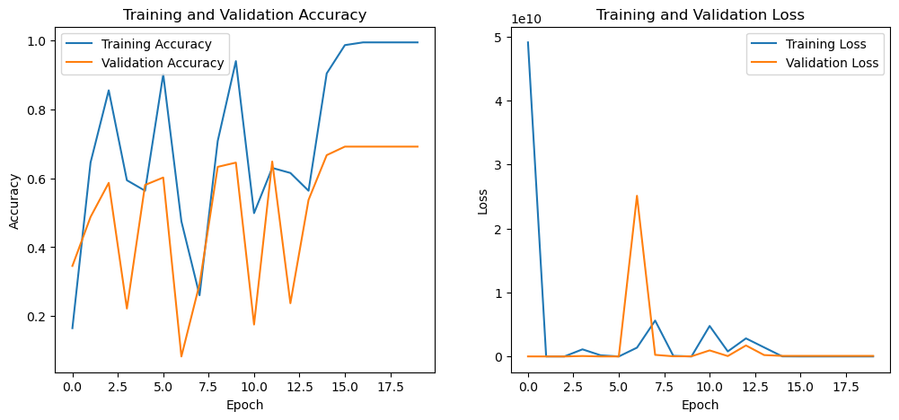

```python
# Plot of Training and Validation Accuracy
plt.figure(figsize=(12, 5))

plt.subplot(1, 2, 1)
plt.plot(history.history['accuracy'], label='Training Accuracy')
plt.plot(history.history['val_accuracy'], label='Validation Accuracy')
plt.title('Training and Validation Accuracy')
plt.xlabel('Epoch')
plt.ylabel('Accuracy')
plt.legend()

# Plot of Training and Validation Loss
plt.subplot(1, 2, 2)
plt.plot(history.history['loss'], label='Training Loss')
plt.plot(history.history['val_loss'], label='Validation Loss')
plt.title('Training and Validation Loss')
plt.xlabel('Epoch')
plt.ylabel('Loss')
plt.legend()

plt.show()
```

Result: The plots demonstrate strong performance on the training data but unstable and fluctuating results on the validation set, indicating overfitting and limited generalization to unseen data.

```
11/11 ━━━━━━━━━━━━━━━━━━━━ 2s 180ms/step
```

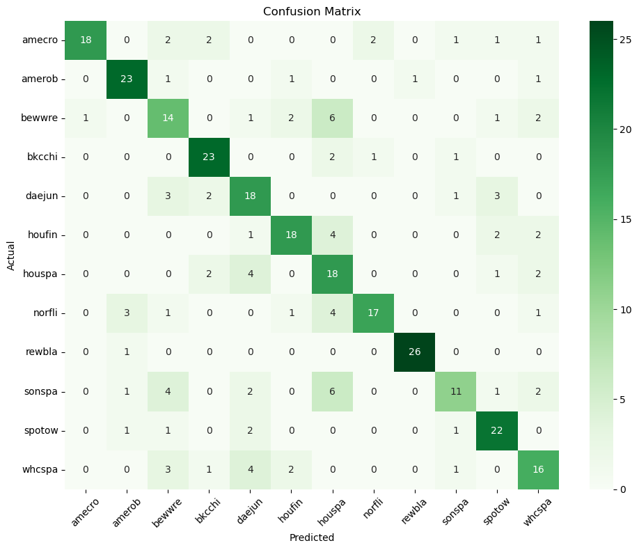

```
              precision    recall  f1-score   support

      amecro       0.95      0.67      0.78        27
      amerob       0.79      0.85      0.82        27
      bewwre       0.48      0.52      0.50        27
      bkcchi       0.77      0.85      0.81        27
      daejun       0.56      0.67      0.61        27
      houfin       0.75      0.67      0.71        27
      houspa       0.45      0.67      0.54        27
      norfli       0.85      0.63      0.72        27
      rewbla       0.96      0.96      0.96        27
      sonspa       0.69      0.41      0.51        27
      spotow       0.71      0.81      0.76        27
      whcspa       0.59      0.59      0.59        27

    accuracy                           0.69       324
   macro avg       0.71      0.69      0.69       324
weighted avg       0.71      0.69      0.69       324
```

```python
# Confusion Matrix

y_pred = cnn_multi_model1.predict(X_test)
y_pred_classes = np.argmax(y_pred, axis=1)
y_true = np.argmax(y_test, axis=1)

conf_matrix4 = confusion_matrix(y_true, y_pred_classes)

plt.figure(figsize=(10, 8))
sns.heatmap(conf_matrix4, annot=True, fmt='d', cmap='Greens', xticklabels=encoder.classes_, yticklabels=encoder.classes_)
plt.xlabel('Predicted')
plt.ylabel('Actual')
plt.title('Confusion Matrix')
plt.xticks(rotation=45)
plt.tight_layout()
plt.show()

print(classification_report(y_true, y_pred_classes, target_names=encoder.classes_, zero_division=0))
```

Result: The multi-class CNN model achieved an overall accuracy of 69% across 12 bird species. These birds can be detected by the model, as indicated by amecro, amerob, bkcchi, houfin, norfli, rewbla, and spotow.

# 3.2 Multi-class CNN Model_2

```python
# Multiclass CNN model
cnn_multi_model2 = Sequential([
    Input(shape=(256, 343, 1)),
    Conv2D(32, (3, 3), activation='relu', kernel_regularizer=l2(0.001)),
    BatchNormalization(),
    MaxPooling2D((2, 2)),

    Conv2D(64, (3, 3), activation='relu', kernel_regularizer=l2(0.001)),
    BatchNormalization(),
    MaxPooling2D((2, 2)),

    Conv2D(128, (3, 3), activation='relu', kernel_regularizer=l2(0.001)),
    BatchNormalization(),
    MaxPooling2D((2, 2)),

    Flatten(),
    Dropout(0.5),
    Dense(128, activation='relu', kernel_regularizer=l2(0.001)),
    Dense(12, activation='softmax')
])

# Compile
cnn_multi_model2.compile(optimizer='adam', loss='categorical_crossentropy', metrics=['accuracy'])
cnn_multi_model2.summary()

# Start Time
start_time = time.time()

# Train
history = cnn_multi_model2.fit(X_train, y_train, epochs=50, batch_size=64, validation_data=(X_test, y_test))

# End time
end_time = time.time()

# Evaluate
loss, accuracy = cnn_multi_model2.evaluate(X_test, y_test)
print("Test accuracy:", accuracy)

train_score = cnn_multi_model2.evaluate(X_train, y_train, verbose=0)
print("Train Accuracy: {:.2f}%".format(train_score[1]*100))

test_score = cnn_multi_model2.evaluate(X_test, y_test, verbose=0)
print("Test Accuracy: {:.2f}%".format(test_score[1]*100))

elapsed_time = end_time - start_time
print(f"\nTraining time: {elapsed_time:.2f} seconds ({elapsed_time / 60:.2f} minutes)")
```

```
Model: "sequential_23"
```

```
┏━━━━━━━━━━━━━━━━━━━━━━━━━━━━━━━━━┳━━━━━━━━━━━━━━━━━━━━━━━━┳━━━━━━━━━━━━━━━┓
┃ Layer (type)                    ┃ Output Shape           ┃       Param # ┃
┡━━━━━━━━━━━━━━━━━━━━━━━━━━━━━━━━━╇━━━━━━━━━━━━━━━━━━━━━━━━╇━━━━━━━━━━━━━━━┩
│ conv2d_62 (Conv2D)              │ (None, 254, 341, 32)   │           320 │
├─────────────────────────────────┼────────────────────────┼───────────────┤
│ batch_normalization_58          │ (None, 254, 341, 32)   │           128 │
│ (BatchNormalization)            │                        │               │
├─────────────────────────────────┼────────────────────────┼───────────────┤
│ max_pooling2d_62 (MaxPooling2D) │ (None, 127, 170, 32)   │             0 │
├─────────────────────────────────┼────────────────────────┼───────────────┤
│ conv2d_63 (Conv2D)              │ (None, 125, 168, 64)   │        18,496 │
├─────────────────────────────────┼────────────────────────┼───────────────┤
│ batch_normalization_59          │ (None, 125, 168, 64)   │           256 │
│ (BatchNormalization)            │                        │               │
├─────────────────────────────────┼────────────────────────┼───────────────┤
│ max_pooling2d_63 (MaxPooling2D) │ (None, 62, 84, 64)     │             0 │
├─────────────────────────────────┼────────────────────────┼───────────────┤
│ conv2d_64 (Conv2D)              │ (None, 60, 82, 128)    │        73,856 │
├─────────────────────────────────┼────────────────────────┼───────────────┤
│ batch_normalization_60          │ (None, 60, 82, 128)    │           512 │
│ (BatchNormalization)            │                        │               │
├─────────────────────────────────┼────────────────────────┼───────────────┤
│ max_pooling2d_64 (MaxPooling2D) │ (None, 30, 41, 128)    │             0 │
├─────────────────────────────────┼────────────────────────┼───────────────┤
│ flatten_23 (Flatten)            │ (None, 157440)         │             0 │
├─────────────────────────────────┼────────────────────────┼───────────────┤
│ dropout_21 (Dropout)            │ (None, 157440)         │             0 │
├─────────────────────────────────┼────────────────────────┼───────────────┤
│ dense_46 (Dense)                │ (None, 128)            │    20,152,448 │
├─────────────────────────────────┼────────────────────────┼───────────────┤
│ dense_47 (Dense)                │ (None, 12)             │         1,548 │
└─────────────────────────────────┴────────────────────────┴───────────────┘
```

```
 Total params: 20,247,564 (77.24 MB)
```

```
 Trainable params: 20,247,116 (77.24 MB)
```

```
 Non-trainable params: 448 (1.75 KB)
```

```
12/12 ━━━━━━━━━━━━━━━━━━━━ 39s 3s/step - accuracy: 0.2297 - loss: 13.9653 - val_accuracy: 0.1481 - val_loss: 11.5748
12/12 ━━━━━━━━━━━━━━━━━━━━ 43s 4s/step - accuracy: 0.5078 - loss: 2.9705 - val_accuracy: 0.1543 - val_loss: 3.9071
12/12 ━━━━━━━━━━━━━━━━━━━━ 45s 4s/step - accuracy: 0.6521 - loss: 2.1505 - val_accuracy: 0.2284 - val_loss: 4.7508
12/12 ━━━━━━━━━━━━━━━━━━━━ 45s 4s/step - accuracy: 0.7617 - loss: 1.7213 - val_accuracy: 0.2778 - val_loss: 3.8535
12/12 ━━━━━━━━━━━━━━━━━━━━ 45s 4s/step - accuracy: 0.8702 - loss: 1.4396 - val_accuracy: 0.3673 - val_loss: 3.6019
12/12 ━━━━━━━━━━━━━━━━━━━━ 44s 4s/step - accuracy: 0.9234 - loss: 1.2939 - val_accuracy: 0.3920 - val_loss: 3.8170
12/12 ━━━━━━━━━━━━━━━━━━━━ 46s 4s/step - accuracy: 0.9522 - loss: 1.2174 - val_accuracy: 0.3889 - val_loss: 4.1556
12/12 ━━━━━━━━━━━━━━━━━━━━ 46s 4s/step - accuracy: 0.9686 - loss: 1.1305 - val_accuracy: 0.4321 - val_loss: 4.1379
12/12 ━━━━━━━━━━━━━━━━━━━━ 44s 4s/step - accuracy: 0.9677 - loss: 1.1722 - val_accuracy: 0.4444 - val_loss: 4.0154
12/12 ━━━━━━━━━━━━━━━━━━━━ 46s 4s/step - accuracy: 0.9685 - loss: 1.0796 - val_accuracy: 0.4877 - val_loss: 3.5312
12/12 ━━━━━━━━━━━━━━━━━━━━ 45s 4s/step - accuracy: 0.9502 - loss: 1.0975 - val_accuracy: 0.3858 - val_loss: 3.7254
12/12 ━━━━━━━━━━━━━━━━━━━━ 44s 4s/step - accuracy: 0.9710 - loss: 1.0598 - val_accuracy: 0.4630 - val_loss: 3.2917
12/12 ━━━━━━━━━━━━━━━━━━━━ 45s 4s/step - accuracy: 0.9733 - loss: 1.0167 - val_accuracy: 0.4907 - val_loss: 3.6445
12/12 ━━━━━━━━━━━━━━━━━━━━ 44s 4s/step - accuracy: 0.9681 - loss: 1.0812 - val_accuracy: 0.5062 - val_loss: 3.7857
12/12 ━━━━━━━━━━━━━━━━━━━━ 43s 4s/step - accuracy: 0.9733 - loss: 1.0019 - val_accuracy: 0.5772 - val_loss: 4.9178
12/12 ━━━━━━━━━━━━━━━━━━━━ 45s 4s/step - accuracy: 0.9750 - loss: 0.9935 - val_accuracy: 0.6420 - val_loss: 5.0370
12/12 ━━━━━━━━━━━━━━━━━━━━ 44s 4s/step - accuracy: 0.9583 - loss: 1.0069 - val_accuracy: 0.5463 - val_loss: 5.8425
12/12 ━━━━━━━━━━━━━━━━━━━━ 43s 4s/step - accuracy: 0.9645 - loss: 1.0703 - val_accuracy: 0.5494 - val_loss: 5.5202
12/12 ━━━━━━━━━━━━━━━━━━━━ 45s 4s/step - accuracy: 0.9643 - loss: 1.0262 - val_accuracy: 0.6481 - val_loss: 4.1426
12/12 ━━━━━━━━━━━━━━━━━━━━ 44s 4s/step - accuracy: 0.9660 - loss: 0.9643 - val_accuracy: 0.6790 - val_loss: 4.3000
12/12 ━━━━━━━━━━━━━━━━━━━━ 41s 3s/step - accuracy: 0.9820 - loss: 0.9393 - val_accuracy: 0.6852 - val_loss: 4.5981
12/12 ━━━━━━━━━━━━━━━━━━━━ 42s 4s/step - accuracy: 0.9833 - loss: 0.9349 - val_accuracy: 0.6296 - val_loss: 5.3026
12/12 ━━━━━━━━━━━━━━━━━━━━ 46s 4s/step - accuracy: 0.9837 - loss: 0.9130 - val_accuracy: 0.4877 - val_loss: 7.2578
12/12 ━━━━━━━━━━━━━━━━━━━━ 41s 3s/step - accuracy: 0.9668 - loss: 1.0181 - val_accuracy: 0.5895 - val_loss: 5.8504
12/12 ━━━━━━━━━━━━━━━━━━━━ 44s 4s/step - accuracy: 0.9510 - loss: 1.0292 - val_accuracy: 0.5957 - val_loss: 7.2738
12/12 ━━━━━━━━━━━━━━━━━━━━ 44s 4s/step - accuracy: 0.9407 - loss: 1.2121 - val_accuracy: 0.6327 - val_loss: 7.8546
12/12 ━━━━━━━━━━━━━━━━━━━━ 48s 4s/step - accuracy: 0.9241 - loss: 1.3156 - val_accuracy: 0.6235 - val_loss: 5.4000
12/12 ━━━━━━━━━━━━━━━━━━━━ 46s 4s/step - accuracy: 0.9294 - loss: 1.4879 - val_accuracy: 0.4506 - val_loss: 6.8366
12/12 ━━━━━━━━━━━━━━━━━━━━ 43s 4s/step - accuracy: 0.9614 - loss: 1.2419 - val_accuracy: 0.4722 - val_loss: 7.3543
12/12 ━━━━━━━━━━━━━━━━━━━━ 43s 4s/step - accuracy: 0.9767 - loss: 1.2830 - val_accuracy: 0.5802 - val_loss: 6.4495
12/12 ━━━━━━━━━━━━━━━━━━━━ 42s 4s/step - accuracy: 0.9781 - loss: 1.2017 - val_accuracy: 0.5617 - val_loss: 8.9832
12/12 ━━━━━━━━━━━━━━━━━━━━ 43s 4s/step - accuracy: 0.9762 - loss: 1.2311 - val_accuracy: 0.6821 - val_loss: 6.5951
12/12 ━━━━━━━━━━━━━━━━━━━━ 43s 4s/step - accuracy: 0.9789 - loss: 1.2204 - val_accuracy: 0.6389 - val_loss: 6.4001
12/12 ━━━━━━━━━━━━━━━━━━━━ 42s 4s/step - accuracy: 0.9808 - loss: 1.2492 - val_accuracy: 0.6019 - val_loss: 6.7527
12/12 ━━━━━━━━━━━━━━━━━━━━ 42s 4s/step - accuracy: 0.9906 - loss: 1.1821 - val_accuracy: 0.6049 - val_loss: 6.1467
12/12 ━━━━━━━━━━━━━━━━━━━━ 42s 4s/step - accuracy: 0.9903 - loss: 1.1623 - val_accuracy: 0.6512 - val_loss: 5.8432
12/12 ━━━━━━━━━━━━━━━━━━━━ 42s 3s/step - accuracy: 0.9919 - loss: 1.1311 - val_accuracy: 0.6759 - val_loss: 5.7036
12/12 ━━━━━━━━━━━━━━━━━━━━ 43s 4s/step - accuracy: 0.9919 - loss: 1.1004 - val_accuracy: 0.6821 - val_loss: 5.6993
12/12 ━━━━━━━━━━━━━━━━━━━━ 47s 4s/step - accuracy: 0.9919 - loss: 1.0673 - val_accuracy: 0.6852 - val_loss: 5.7475
12/12 ━━━━━━━━━━━━━━━━━━━━ 230s 20s/step - accuracy: 0.9894 - loss: 1.0757 - val_accuracy: 0.7130 - val_loss: 5.6141
12/12 ━━━━━━━━━━━━━━━━━━━━ 268s 20s/step - accuracy: 0.9893 - loss: 1.0224 - val_accuracy: 0.6728 - val_loss: 5.3839
12/12 ━━━━━━━━━━━━━━━━━━━━ 214s 18s/step - accuracy: 0.9889 - loss: 1.0102 - val_accuracy: 0.7099 - val_loss: 4.6407
12/12 ━━━━━━━━━━━━━━━━━━━━ 211s 18s/step - accuracy: 0.9888 - loss: 1.0554 - val_accuracy: 0.7006 - val_loss: 4.5332
12/12 ━━━━━━━━━━━━━━━━━━━━ 201s 17s/step - accuracy: 0.9910 - loss: 0.9509 - val_accuracy: 0.6481 - val_loss: 4.6875
12/12 ━━━━━━━━━━━━━━━━━━━━ 99s 8s/step - accuracy: 0.9813 - loss: 0.9661 - val_accuracy: 0.6790 - val_loss: 5.9280
12/12 ━━━━━━━━━━━━━━━━━━━━ 83s 7s/step - accuracy: 0.9864 - loss: 0.9450 - val_accuracy: 0.6790 - val_loss: 6.8749
12/12 ━━━━━━━━━━━━━━━━━━━━ 85s 7s/step - accuracy: 0.9815 - loss: 0.9846 - val_accuracy: 0.6636 - val_loss: 7.0585
12/12 ━━━━━━━━━━━━━━━━━━━━ 48s 4s/step - accuracy: 0.9700 - loss: 1.0790 - val_accuracy: 0.6327 - val_loss: 5.6312
12/12 ━━━━━━━━━━━━━━━━━━━━ 44s 4s/step - accuracy: 0.9829 - loss: 0.9939 - val_accuracy: 0.7315 - val_loss: 5.2000
12/12 ━━━━━━━━━━━━━━━━━━━━ 42s 4s/step - accuracy: 0.9717 - loss: 1.0557 - val_accuracy: 0.7160 - val_loss: 5.2335
11/11 ━━━━━━━━━━━━━━━━━━━━ 3s 273ms/step - accuracy: 0.6958 - loss: 5.1129
Test accuracy: 0.7160493731498718
Train Accuracy: 95.37%
Test Accuracy: 71.60%

Training time: 3233.13 seconds (53.89 minutes)
```

Result: The second Multi-class CNN model reached 95.4% accuracy on training data and 72% on test data. The test accuracy reveals a performance drop on unseen data, which suggests overfitting. While the model generalizes moderately well than the previous model.

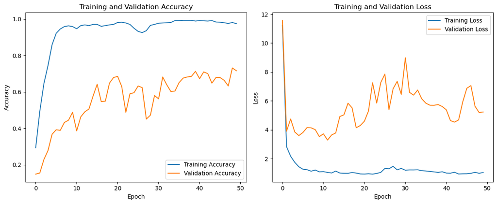

```python
# Plot of Training and Validation Accuracy
plt.figure(figsize=(12, 5))

plt.subplot(1, 2, 1)
plt.plot(history.history['accuracy'], label='Training Accuracy')
plt.plot(history.history['val_accuracy'], label='Validation Accuracy')
plt.title('Training and Validation Accuracy')
plt.xlabel('Epoch')
plt.ylabel('Accuracy')
plt.legend()

# Plot of Training and Validation Loss
plt.subplot(1, 2, 2)
plt.plot(history.history['loss'], label='Training Loss')
plt.plot(history.history['val_loss'], label='Validation Loss')
plt.title('Training and Validation Loss')
plt.xlabel('Epoch')
plt.ylabel('Loss')
plt.legend()

plt.tight_layout()
plt.show()
```

Result: Although this plot shows very high training accuracy, validation accuracy improves slowly and fluctuates, resulting in high validation loss. This indicates overfitting. The model learns well from the training data but struggles to generalize to unseen data.

```
11/11 ━━━━━━━━━━━━━━━━━━━━ 2s 197ms/step
```

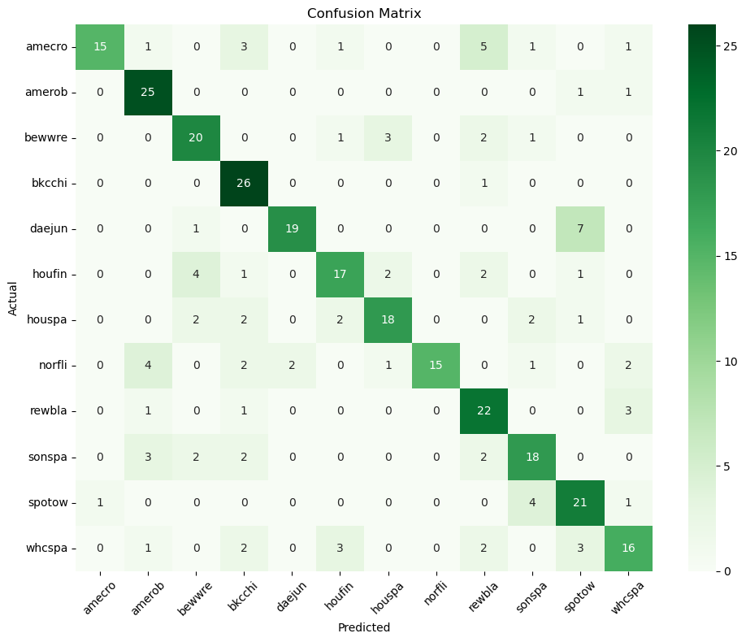

```
              precision    recall  f1-score   support

      amecro       0.94      0.56      0.70        27
      amerob       0.71      0.93      0.81        27
      bewwre       0.69      0.74      0.71        27
      bkcchi       0.67      0.96      0.79        27
      daejun       0.90      0.70      0.79        27
      houfin       0.71      0.63      0.67        27
      houspa       0.75      0.67      0.71        27
      norfli       1.00      0.56      0.71        27
      rewbla       0.61      0.81      0.70        27
      sonspa       0.67      0.67      0.67        27
      spotow       0.62      0.78      0.69        27
      whcspa       0.67      0.59      0.63        27

    accuracy                           0.72       324
   macro avg       0.74      0.72      0.71       324
weighted avg       0.74      0.72      0.71       324
```

```python
# Confusion Matrix

# Predict
y_pred = cnn_multi_model2.predict(X_test)
y_pred_classes = np.argmax(y_pred, axis=1)
y_true = np.argmax(y_test, axis=1)

# Confusion Matrix
conf_matrix5 = confusion_matrix(y_true, y_pred_classes)

plt.figure(figsize=(10, 8))
sns.heatmap(conf_matrix5, annot=True, fmt='d', cmap='Greens', xticklabels=encoder.classes_, yticklabels=encoder.classes_)
plt.xlabel('Predicted')
plt.ylabel('Actual')
plt.title('Confusion Matrix')
plt.xticks(rotation=45)
plt.yticks(rotation=0)
plt.tight_layout()
plt.show()

# Classification Report
print(classification_report(y_true, y_pred_classes, target_names=encoder.classes_, zero_division=0))
```

Result: The second multi-class CNN model achieved an overall accuracy of 72% across 12 bird species. These birds can be detected by models, as indicated by amerob, bkcchi, and daejun.

# 3.3 Tuned Multi-class CNN Model

```python
# Define number of classes based on your encoded data
num_classes = y_train.shape[1]

# Tuned Multi-class CNN model
cnn_multi_model3 = Sequential([
    Input(shape=(256, 343, 1)),

    Conv2D(32, (3, 3), activation='relu', kernel_regularizer=l2(0.001)),
    BatchNormalization(),
    MaxPooling2D((2, 2)),

    Conv2D(64, (3, 3), activation='relu', kernel_regularizer=l2(0.001)),
    BatchNormalization(),
    MaxPooling2D((2, 2)),

    Conv2D(128, (3, 3), activation='relu', kernel_regularizer=l2(0.001)),
    BatchNormalization(),
    MaxPooling2D((2, 2)),

    Flatten(),
    Dropout(0.6),
    Dense(128, activation='relu'),
    Dense(num_classes, activation='softmax')
])

# Compile
cnn_multi_model3.compile(optimizer='adam', loss='categorical_crossentropy', metrics=['accuracy'])
cnn_multi_model3.summary()

# Start Time
start_time = time.time()

# Early stopping
early_stop = EarlyStopping(monitor='val_loss', patience=5, restore_best_weights=True)
reduce_lr = ReduceLROnPlateau(monitor='val_loss', factor=0.5, patience=3)

# Train
history = cnn_multi_model3.fit(X_train, y_train, epochs=50, batch_size=32, validation_data=(X_test, y_test), callbacks=[early_stop, reduce_lr])

# End time
end_time = time.time()

# Evaluate model
test_loss, test_accuracy = cnn_multi_model3.evaluate(X_test, y_test)
print("Test accuracy:", test_accuracy)

train_score = cnn_multi_model3.evaluate(X_train, y_train, verbose=0)
print("Train Accuracy: {:.2f}%".format(train_score[1]*100))

test_score = cnn_multi_model3.evaluate(X_test, y_test, verbose=0)
print("Test Accuracy: {:.2f}%".format(test_score[1]*100))

elapsed_time = end_time - start_time
print(f"\nTraining time: {elapsed_time:.2f} seconds ({elapsed_time / 60:.2f} minutes)")
```

```
Model: "sequential"
```

```
┏━━━━━━━━━━━━━━━━━━━━━━━━━━━━━━━━━┳━━━━━━━━━━━━━━━━━━━━━━━━┳━━━━━━━━━━━━━━━┓
┃ Layer (type)                    ┃ Output Shape           ┃       Param # ┃
┡━━━━━━━━━━━━━━━━━━━━━━━━━━━━━━━━━╇━━━━━━━━━━━━━━━━━━━━━━━━╇━━━━━━━━━━━━━━━┩
│ conv2d (Conv2D)                 │ (None, 254, 341, 32)   │           320 │
├─────────────────────────────────┼────────────────────────┼───────────────┤
│ batch_normalization             │ (None, 254, 341, 32)   │           128 │
│ (BatchNormalization)            │                        │               │
├─────────────────────────────────┼────────────────────────┼───────────────┤
│ max_pooling2d (MaxPooling2D)    │ (None, 127, 170, 32)   │             0 │
├─────────────────────────────────┼────────────────────────┼───────────────┤
│ conv2d_1 (Conv2D)               │ (None, 125, 168, 64)   │        18,496 │
├─────────────────────────────────┼────────────────────────┼───────────────┤
│ batch_normalization_1           │ (None, 125, 168, 64)   │           256 │
│ (BatchNormalization)            │                        │               │
├─────────────────────────────────┼────────────────────────┼───────────────┤
│ max_pooling2d_1 (MaxPooling2D)  │ (None, 62, 84, 64)     │             0 │
├─────────────────────────────────┼────────────────────────┼───────────────┤
│ conv2d_2 (Conv2D)               │ (None, 60, 82, 128)    │        73,856 │
├─────────────────────────────────┼────────────────────────┼───────────────┤
│ batch_normalization_2           │ (None, 60, 82, 128)    │           512 │
│ (BatchNormalization)            │                        │               │
├─────────────────────────────────┼────────────────────────┼───────────────┤
│ max_pooling2d_2 (MaxPooling2D)  │ (None, 30, 41, 128)    │             0 │
├─────────────────────────────────┼────────────────────────┼───────────────┤
│ flatten (Flatten)               │ (None, 157440)         │             0 │
├─────────────────────────────────┼────────────────────────┼───────────────┤
│ dropout (Dropout)               │ (None, 157440)         │             0 │
├─────────────────────────────────┼────────────────────────┼───────────────┤
│ dense (Dense)                   │ (None, 128)            │    20,152,448 │
├─────────────────────────────────┼────────────────────────┼───────────────┤
│ dense_1 (Dense)                 │ (None, 12)             │         1,548 │
└─────────────────────────────────┴────────────────────────┴───────────────┘
```

```
 Total params: 20,247,564 (77.24 MB)
```

```
 Trainable params: 20,247,116 (77.24 MB)
```

```
 Non-trainable params: 448 (1.75 KB)
```

```
24/24 ━━━━━━━━━━━━━━━━━━━━ 33s 1s/step - accuracy: 0.1906 - loss: 13.7903 - val_accuracy: 0.0957 - val_loss: 34.5514 - learning_rate: 0.0010
24/24 ━━━━━━━━━━━━━━━━━━━━ 41s 2s/step - accuracy: 0.3394 - loss: 2.0998 - val_accuracy: 0.1944 - val_loss: 3.5269 - learning_rate: 0.0010
24/24 ━━━━━━━━━━━━━━━━━━━━ 42s 2s/step - accuracy: 0.5376 - loss: 1.7136 - val_accuracy: 0.3086 - val_loss: 5.0029 - learning_rate: 0.0010
24/24 ━━━━━━━━━━━━━━━━━━━━ 41s 2s/step - accuracy: 0.6702 - loss: 1.4234 - val_accuracy: 0.4321 - val_loss: 2.6580 - learning_rate: 0.0010
24/24 ━━━━━━━━━━━━━━━━━━━━ 42s 2s/step - accuracy: 0.7590 - loss: 0.9003 - val_accuracy: 0.4969 - val_loss: 2.6654 - learning_rate: 0.0010
24/24 ━━━━━━━━━━━━━━━━━━━━ 42s 2s/step - accuracy: 0.7925 - loss: 0.6867 - val_accuracy: 0.4691 - val_loss: 2.9221 - learning_rate: 0.0010
24/24 ━━━━━━━━━━━━━━━━━━━━ 42s 2s/step - accuracy: 0.8389 - loss: 0.6813 - val_accuracy: 0.5926 - val_loss: 2.7829 - learning_rate: 0.0010
24/24 ━━━━━━━━━━━━━━━━━━━━ 42s 2s/step - accuracy: 0.8634 - loss: 0.5404 - val_accuracy: 0.6574 - val_loss: 2.4770 - learning_rate: 5.0000e-04
24/24 ━━━━━━━━━━━━━━━━━━━━ 42s 2s/step - accuracy: 0.9021 - loss: 0.4072 - val_accuracy: 0.6728 - val_loss: 2.4679 - learning_rate: 5.0000e-04
24/24 ━━━━━━━━━━━━━━━━━━━━ 41s 2s/step - accuracy: 0.9241 - loss: 0.3588 - val_accuracy: 0.6759 - val_loss: 2.7702 - learning_rate: 5.0000e-04
24/24 ━━━━━━━━━━━━━━━━━━━━ 42s 2s/step - accuracy: 0.9399 - loss: 0.3262 - val_accuracy: 0.7222 - val_loss: 2.3608 - learning_rate: 5.0000e-04
24/24 ━━━━━━━━━━━━━━━━━━━━ 40s 2s/step - accuracy: 0.9597 - loss: 0.2562 - val_accuracy: 0.7222 - val_loss: 2.5950 - learning_rate: 5.0000e-04
24/24 ━━━━━━━━━━━━━━━━━━━━ 42s 2s/step - accuracy: 0.9619 - loss: 0.2461 - val_accuracy: 0.7377 - val_loss: 2.5925 - learning_rate: 5.0000e-04
24/24 ━━━━━━━━━━━━━━━━━━━━ 42s 2s/step - accuracy: 0.9725 - loss: 0.2166 - val_accuracy: 0.7593 - val_loss: 2.4478 - learning_rate: 5.0000e-04
24/24 ━━━━━━━━━━━━━━━━━━━━ 43s 2s/step - accuracy: 0.9734 - loss: 0.2071 - val_accuracy: 0.7623 - val_loss: 2.3301 - learning_rate: 2.5000e-04
24/24 ━━━━━━━━━━━━━━━━━━━━ 42s 2s/step - accuracy: 0.9753 - loss: 0.1961 - val_accuracy: 0.7716 - val_loss: 2.3508 - learning_rate: 2.5000e-04
24/24 ━━━━━━━━━━━━━━━━━━━━ 40s 2s/step - accuracy: 0.9783 - loss: 0.1886 - val_accuracy: 0.7778 - val_loss: 2.3463 - learning_rate: 2.5000e-04
24/24 ━━━━━━━━━━━━━━━━━━━━ 40s 2s/step - accuracy: 0.9837 - loss: 0.1806 - val_accuracy: 0.7685 - val_loss: 2.3993 - learning_rate: 2.5000e-04
24/24 ━━━━━━━━━━━━━━━━━━━━ 41s 2s/step - accuracy: 0.9799 - loss: 0.1761 - val_accuracy: 0.7685 - val_loss: 2.3928 - learning_rate: 1.2500e-04
24/24 ━━━━━━━━━━━━━━━━━━━━ 42s 2s/step - accuracy: 0.9834 - loss: 0.1733 - val_accuracy: 0.7716 - val_loss: 2.3745 - learning_rate: 1.2500e-04
11/11 ━━━━━━━━━━━━━━━━━━━━ 3s 251ms/step - accuracy: 0.7321 - loss: 2.3242
Test accuracy: 0.7623456716537476
Train Accuracy: 96.30%
Test Accuracy: 76.23%

Training time: 824.77 seconds (13.75 minutes)
```

[figure not shown]

```python
# Plot of Training and Validation Accuracy
plt.figure(figsize=(12, 5))

plt.subplot(1, 2, 1)
plt.plot(history.history['accuracy'], label='Training Accuracy')
plt.plot(history.history['val_accuracy'], label='Validation Accuracy')
plt.title('Training and Validation Accuracy')
plt.xlabel('Epoch')
plt.ylabel('Accuracy')
plt.legend()

# Plot of Training and Validation Loss
plt.subplot(1, 2, 2)
plt.plot(history.history['loss'], label='Training Loss')
plt.plot(history.history['val_loss'], label='Validation Loss')
plt.title('Training and Validation Loss')
plt.xlabel('Epoch')
plt.ylabel('Loss')
plt.legend()

plt.tight_layout()
plt.show()
```

Result: The tuned multi-class CNN model demonstrates strong learning ability and good generalization. Although validation accuracy is slightly less than training, the steady upward trend and steady loss indicate a well-trained and reliable CNN for identifying multiple bird species.

```
11/11 ━━━━━━━━━━━━━━━━━━━━ 2s 212ms/step
```

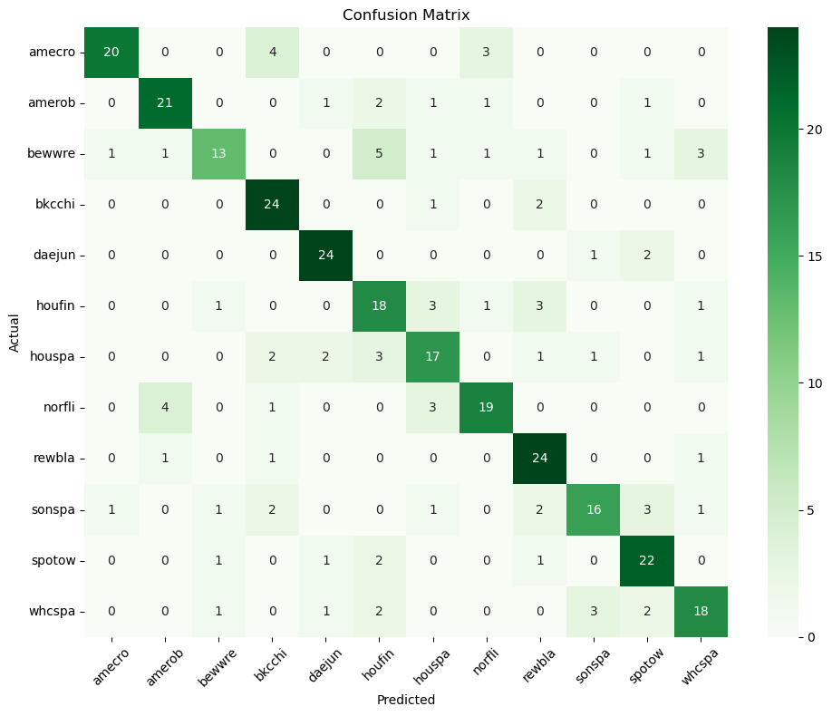

```
              precision    recall  f1-score   support

      amecro       0.91      0.74      0.82        27
      amerob       0.78      0.78      0.78        27
      bewwre       0.76      0.48      0.59        27
      bkcchi       0.71      0.89      0.79        27
      daejun       0.83      0.89      0.86        27
      houfin       0.56      0.67      0.61        27
      houspa       0.63      0.63      0.63        27
      norfli       0.76      0.70      0.73        27
      rewbla       0.71      0.89      0.79        27
      sonspa       0.76      0.59      0.67        27
      spotow       0.71      0.81      0.76        27
      whcspa       0.72      0.67      0.69        27

    accuracy                           0.73       324
   macro avg       0.74      0.73      0.73       324
weighted avg       0.74      0.73      0.73       324
```

```python
# Confusion Matrix

y_pred = cnn_multi_model3.predict(X_test)
y_pred_classes = np.argmax(y_pred, axis=1)
y_true = np.argmax(y_test, axis=1)

conf_matrix6 = confusion_matrix(y_true, y_pred_classes)
plt.figure(figsize=(10, 8))
sns.heatmap(conf_matrix6, annot=True, fmt='d', cmap='Greens',
            xticklabels=encoder.classes_, yticklabels=encoder.classes_)
plt.xlabel('Predicted')
plt.ylabel('Actual')
plt.title('Confusion Matrix')
plt.xticks(rotation=45)
plt.tight_layout()
plt.show()

# Classification Report with zero_division fix
print(classification_report(
    y_true,
    y_pred_classes,
    target_names=encoder.classes_,
    zero_division=0  # <== this suppresses warning and safely assigns 0
))
```

Result: The Tuned multi-class CNN model achieved an overall accuracy of 73% across 12 bird species. The model performed best on species such as daejun and amecro are showing both high precision, F1-score, and recall. Conversely, species like bewwre and houfin were more difficult to classify.

# 4.External Test Data

```
test1.mp3 predictions:
  spotow: 1 times
  sonspa: 1 times
  houfin: 5 times
  norfli: 2 times
  bkcchi: 2 times

test2.mp3 predictions:
  houfin: 2 times

test3.mp3 predictions:
  houfin: 3 times
  sonspa: 1 times
  norfli: 1 times
  bkcchi: 2 times
```

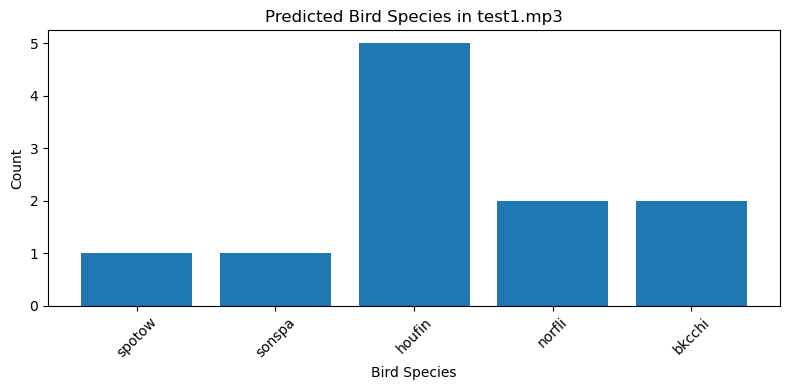

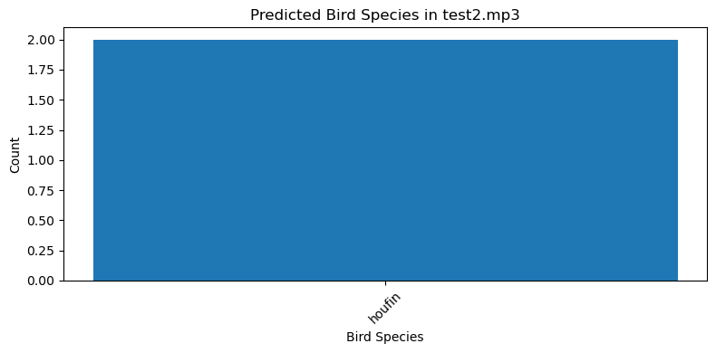

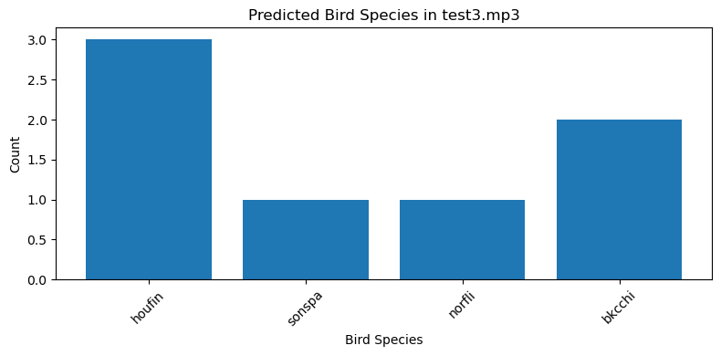

```
Summary Table:

     Clip    Top Species Multi-bird?
test1.mp3         houfin          No
test2.mp3         houfin          No
test3.mp3 houfin, bkcchi         Yes
```

```python
# Function to process .mp3 clips and predict bird species
def predict_bird_species_from_mp3(mp3_path, model, encoder, desired_shape=(256, 343), sr=22050):
    y, _ = librosa.load(mp3_path, sr=sr)
    segment_duration = 2
    segment_length = sr * segment_duration

    predictions = []

    for i in range(0, len(y), segment_length):
        segment = y[i:i + segment_length]
        if len(segment) < segment_length:
            continue

        # Convert to Mel Spectrogram
        mel_spec = librosa.feature.melspectrogram(y=segment, sr=sr, n_mels=128)
        mel_spec_db = librosa.power_to_db(mel_spec, ref=np.max)

        # Resize to (256, 343)
        resized = cv2.resize(mel_spec_db, desired_shape, interpolation=cv2.INTER_AREA)

        # Normalize and reshape to (1, 256, 343, 1)
        input_array = resized.astype('float32')
        input_array /= (np.max(input_array) + 1e-8)
        input_array = input_array.reshape(1, desired_shape[0], desired_shape[1], 1)

        # Predict
        pred = model.predict(input_array, verbose=0)
        predictions.append(np.argmax(pred))

    return predictions

# Set Paths to MP3 Clips
base_path = r"D:\Data Science Master in USA\Spring_2025\DATA 5322 Statistical Machine Learning II\Homework\Practical Homework 3_Deep Learning"

clip_paths = [
    f"{base_path}\\test1.mp3",
    f"{base_path}\\test2.mp3",
    f"{base_path}\\test3.mp3"
]

# Run Predictions for Each Clip
results = {}

for path in clip_paths:
    preds = predict_bird_species_from_mp3(path, cnn_multi_model3, encoder)
    counts = Counter(preds)
    readable = {encoder.classes_[cls]: count for cls, count in counts.items()}
    results[os.path.basename(path)] = readable

# Print Predictions per Clip
for clip, pred_counts in results.items():
    print(f"\n{clip} predictions:")
    for species, count in pred_counts.items():
        print(f"  {species}: {count} times")

# Plot Bar Chart per Clip
for clip, pred_counts in results.items():
    species = list(pred_counts.keys())
    values = list(pred_counts.values())

    plt.figure(figsize=(8, 4))
    plt.bar(species, values)
    plt.title(f"Predicted Bird Species in {clip}")
    plt.xlabel("Bird Species")
    plt.ylabel("Count")
    plt.xticks(rotation=45)
    plt.tight_layout()
    plt.show()

# Summary Table
summary = []
for clip, pred_counts in results.items():
    total = sum(pred_counts.values())
    dominant = [k for k, v in pred_counts.items() if v / total > 0.2]
    multi = "Yes" if len(dominant) > 1 else "No"
    summary.append({
        "Clip": clip,
        "Top Species": ', '.join(dominant),
        "Multi-bird?": multi
    })

df_summary = pd.DataFrame(summary)
print("\nSummary Table:\n")
print(df_summary.to_string(index=False))
```